# eDNA_exploration_2021

Lia Domke

3/24/2022

We collected nearshore samples from southern Southeast Alaska and amplified the samples using MiFish primer (12S) and quantified using MiSeq Illumina

Goals for this script is to explore the read data - maybe represent it as species proportions by site (although we know that this raw data is not correct in terms of proportions so maybe we skip that).

After exploring species read counds by sites, maybe look at community composition (using presence and absence)

Finally lets compare the species occurences between seine data and eDNA by site

libraries

```r
library(plyr)
library(dplyr)
library(tidyverse)
library(vegan)
library(glue)
library(ggrepel)
```

# Read in data

```r
edna <- read.csv("/Users/liadomke/Desktop/Grad School/UAF/Data/Chp3_SeascapeDynamics/Data/eDNA_tax_filtered_3-24-22.csv")
loc <- read.csv("/Users/liadomke/Desktop/Grad School/UAF/Data/Chp3_SeascapeDynamics/Data/chp3_sites.csv")
seine <- read.csv("/Users/liadomke/Desktop/Grad School/UAF/Data/Chp3_SeascapeDynamics/Data/fish_beach_seine_2021_1-5-21.csv")

edna.minus.control <- read.csv("/Users/liadomke/Desktop/Grad School/UAF/Data/Chp3_SeascapeDynamics/Data/eDNA_tax_filtered_minus_controls_4-15-22.csv", stringsAsFactors = FALSE, header = TRUE)
```

visualize eDNA reads

```r
glimpse(edna)
```

```
## Rows: 2,021
## Columns: 12
## $ X               <int> 1, 2, 3, 4, 5, 6, 7, 8, 9, 10, 11, 12, 13, 14, 15, 16,…
## $ sample.PCR      <chr> "e00005-A", "e00005-A", "e00005-A", "e00005-A", "e0000…
## $ sample          <chr> "e00005", "e00005", "e00005", "e00005", "e00005", "e00…
## $ rep             <chr> "A", "A", "A", "A", "A", "A", "A", "A", "A", "B", "B",…
## $ count           <int> 39, 1678, 1542, 435, 451, 33, 6, 20, 2, 111, 3205, 307…
## $ taxon           <chr> "Clupeidae", "Anoplopoma_fimbria", "Sebastidae", "Gadi…
## $ taxonomic_level <chr> "family", "species", "family", "family", "species", "g…
## $ SampleCode      <chr> NA, NA, NA, NA, NA, NA, NA, NA, NA, NA, NA, NA, NA, NA…
## $ Sample_label    <chr> NA, NA, NA, NA, NA, NA, NA, NA, NA, NA, NA, NA, NA, NA…
## $ Sample_rep      <chr> NA, NA, NA, NA, NA, NA, NA, NA, NA, NA, NA, NA, NA, NA…
## $ Sample_date     <chr> NA, NA, NA, NA, NA, NA, NA, NA, NA, NA, NA, NA, NA, NA…
## $ Extraction_date <chr> NA, NA, NA, NA, NA, NA, NA, NA, NA, NA, NA, NA, NA, NA…
```

```r
unique(edna$taxon)
```

```
##  [1] "Clupeidae"                  "Anoplopoma_fimbria"
##  [3] "Sebastidae"                 "Gadidae"
##  [5] "Anarrhichthys_ocellatus"    "Hexagrammos"
##  [7] "Oncorhynchus"               "Hexagrammos_decagrammus"
##  [9] "Bathymaster"                "Stichaeidae"
## [11] "Enophrys_diceraus"          "Homo_sapiens"
## [13] "Liparis"                    "Salmonidae"
## [15] "Cottidae"                   "Pleuronectidae"
## [17] "Pholis"                     "Icelinus_borealis"
## [19] "Cymatogaster_aggregata"     "Gasterosteus"
## [21] "Clinocottus_acuticeps"      "Actinopteri"
## [23] "Pleuronichthys"             "Polypera_greeni"
## [25] "Citharichthys_stigmaeus"    "Ammodytidae"
## [27] "Oligocottus"                "Syngnathus_leptorhynchus"
## [29] "Anoplarchus"                "Aulorhynchus_flavidus"
```

[output cut: 16 more lines]

remove any sample ID that are not part of my sampling in SESO

```r
edna.red <- edna %>%
  filter(sample != "e00005" & sample != "e00007" & sample != "e00010" & sample != "e00011" &
          sample != "e00012" & sample != "e00013" & sample != "e00014" & sample != "e00015" &
          sample != "e00016" & sample != "e00017") %>%
  select(-X)

edna.red$binary <- ifelse(edna.red$count > 0, 1, 0)
```

add in habitat information

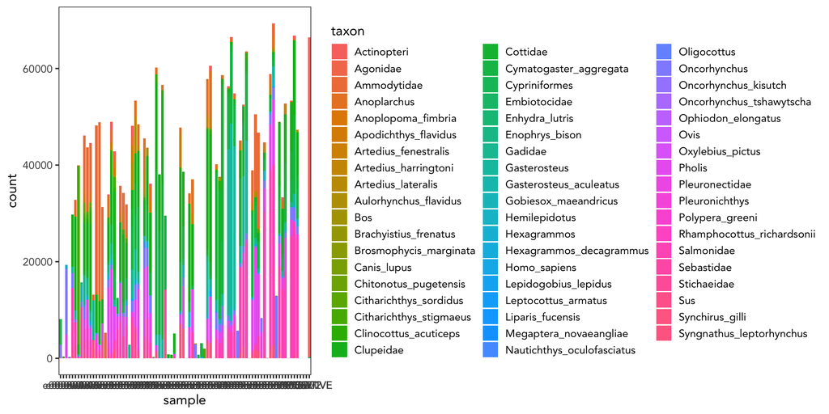

Divide by habitat type

```r
sites <- c("Sylburn harbor eel",  "Sylburn harbor kelp", "Reef harbor eel", "Reef harbor kelp", "Kah shakes eel", "Kah shakes kelp", "Dall bay eel", "Dall bay kelp",
"Moira sound eel", "Moira sound kelp", "Nichols bay eel", "Nichols bay kelp", "Tah bay eel", "Hunter bay eel", "Klawock airport eel", "Big Tree bay eel", "Clam island mixed", "Cole island mixed", "Bostwick inlet eel", "Bostwick inlet kelp")

habitat <- c("eelgrass", "kelp", "eelgrass", "kelp",
             "eelgrass", "kelp", "eelgrass", "kelp",
             "eelgrass", "kelp", "eelgrass", "kelp",
             "mixed eelgrass", "eelgrass", "eelgrass",
             "eelgrass", "mixed eelgrass",
             "mixed eelgrass", "eelgrass", "kelp")

bay_id <- c("SYLB_A", "SYLB_B", "REEF_A", "REEF_B", "KAHS_A", "KAHS_B", "DALL_A", "DALL_B",
            "MOIR_A", "MOIR_B", "NICH_A", "NICH_B", "TAHB_A", "HUNT_A", "KLWA_A", "BTRB_A",
            "CLAM_A", "NFEI_B", "BOST_A", "BOST_B")

chp3 <- data.frame(sites, habitat)

edna.red.hab <- left_join(chp3, edna.red, by = c("sites" = "Sample_label"))

# change to P/A
# sppAbun[sppAbun > 0] <- 1 #converts from abundance to P/A
# sppAbun
```

If we’re interested in accounting for the field controls - subtract the controls by site, from the ASVs collected, this was done in the script “taxonomic_filtering_eDNA2021.Rmd”

# Field controls removed

```r
glimpse(edna.minus.control)
```

```
## Rows: 1,555
## Columns: 11
## $ X                     <int> 1, 2, 3, 4, 5, 6, 7, 8, 9, 10, 11, 12, 13, 14, 1…
## $ sample.PCR            <chr> "e00289-A", "e00289-A", "e00289-B", "e00289-B", …
## $ sample                <chr> "e00289", "e00289", "e00289", "e00289", "e00289"…
## $ taxon                 <chr> "Pholis", "Oncorhynchus", "Salmonidae", "Cymatog…
## $ taxonomic_level       <chr> "genus", "genus", "family", "species", "genus", …
## $ SampleCode            <chr> "2021_SYLB_A_1", "2021_SYLB_A_1", "2021_SYLB_A_1…
## $ Sample_label          <chr> "Sylburn harbor eel", "Sylburn harbor eel", "Syl…
## $ Sample_rep            <int> 1, 1, 1, 1, 1, 1, 1, 1, 2, 3, 3, 3, 3, 3, 3, 3, …
## $ Sample_date           <chr> "6/8/21", "6/8/21", "6/8/21", "6/8/21", "6/8/21"…
## $ Extraction_date       <chr> "11/18/21", "11/18/21", "11/18/21", "11/18/21", …
## $ counts_minus_controls <int> 0, 1110, 0, 2326, 870, 1, 2937, 752, 364, 1, 228…
```

```r
# add in habitat data, like above
edna.nocontrol.hab <- left_join(chp3, edna.minus.control, by = c("sites" = "Sample_label")) %>%
  dplyr::select(-X)

# rotate the dataframe to wide (like below) and create a binary column
edna.nocontrol.hab$binary <- ifelse(edna.nocontrol.hab$counts_minus_controls > 0, 1, 0)

# binary wide
minuscontrol.wide.bin <- edna.nocontrol.hab %>%
  pivot_wider(id_cols = -c(taxonomic_level, counts_minus_controls), names_from = "taxon", values_from = "binary", values_fill = 0) %>%
  distinct()

# make the binary long again better for plotting
minuscontrol.long.bin <- minuscontrol.wide.bin %>%
  pivot_longer(cols = Pholis:Agonidae, names_to = "taxon", values_to = "binary")

# count-based wide then long
minuscontrol.wide.counts <- edna.nocontrol.hab %>%
  pivot_wider(id_cols = -c(taxonomic_level, binary), names_from = "taxon", values_from = "counts_minus_controls", values_fill = 0) %>%
  distinct()

minuscontrol.long.counts <- minuscontrol.wide.counts %>%
  pivot_longer(cols = Pholis:Agonidae, names_to = "taxon", values_to = "counts_minus_controls")
```

# Includes field controls

rotate data frame to wide for dataframe that still includes the control information

```r
edna.wide <- edna.red.hab %>%
  pivot_wider(id_cols = -c(taxonomic_level, binary), names_from = "taxon", values_from = "count", values_fill = 0) %>%
  distinct()

edna.bin.wide <- edna.red.hab %>%
  pivot_wider(id_cols = -c(taxonomic_level, count), names_from = "taxon", values_from = "binary",
                             values_fill = 0) %>%
  distinct()

# take the binary wide dataframe and make it long again for plotting
edna.hab.long <- pivot_longer(edna.bin.wide, cols = Pholis:Agonidae, names_to = "taxon", values_to = "binary")
```

# 1. Visualize by habitat

## eelgrass by sample rep and field rep

The graphs below show the detection (and ASV count) across the 10 eelgrass sites (at 8 of these sites we have seine data). Each field and technical replicate is presented as different bars. Field replicate is represented by the number (1,2,3 or control) and each technical replciate (done in triplicate) is represented by letters (A,B,C).

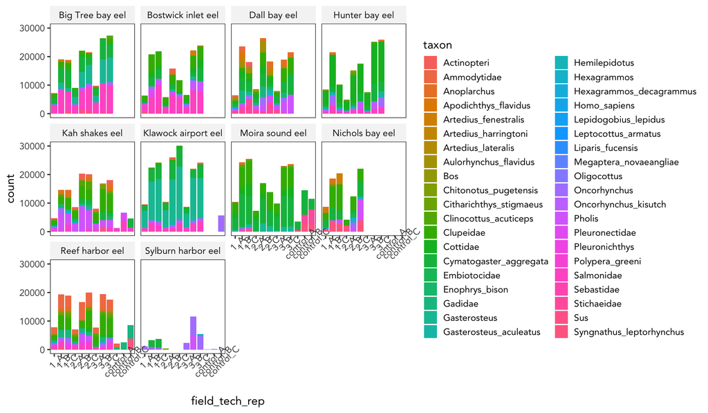

Figure 1: Detection and count of taxon across the eelgrass sites where we have eDNA data and includes controls

The graphs above indicate relative consistency species occurrence (presence) across the technical replicates and even the field replicates. However, there are a few confusing exceptions. In particular Sylburn harbor eelgrass has extremely low species occurence. Samples 1 - A is composed of Oncorhynchus and Pholis, sample 1- B is Cymatogaster_aggregata, Oncorhynchus, 1-C has oncorhnynchus, and Clupeidae. Sample 2 ABC has nearly nothing with A only having Citharichthys_stigmaeus, Ammodytidae, Oligocottus, and Oncorhynchus Sample 3 ABC added hexagrammous to the mix of species present (with others)

*Questions*

- How should we account for the control? Do we subtract the control species from the the presence/absence in the field replicates? Do we substract the ASV read counts of the control from each field sample? <- doing this may be a bad idea because if there was little genetic material in the control and lots of PCR material (nucleotides etc) then it would artificially make the ASV counts of the genetic material there greater than if it was present in a sample with lots of genetic material.
- How do we deal with the technical triplicates? Previously (w/ Ole) we talked about using them to express the stochasity of the data. How do we express a confidence interval w/ presence/absence data?

## understory kelp by field and technical replicates

ASV counts of species present at sites. Includes both the field and technical replicates

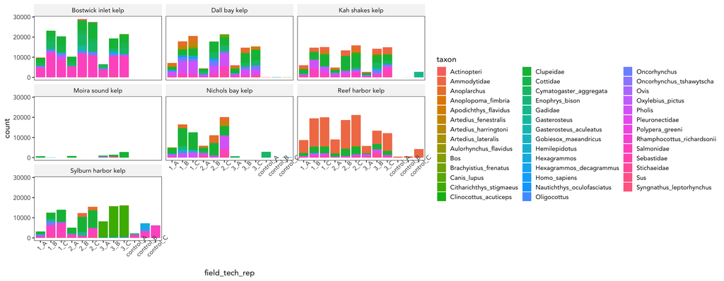

Figure 2: Detection and count of taxon across the understory kelp sites where we have eDNA data and includes controls

These graphs are similar to the eelgrass sites. In this case the sites that have questionable results are: moira sound kelp - with very few ASV counts across the replicates, Nichols bay kelp - almost no species present in the 3rd field replicate, Sylburn harbor klep - with not very consistent results across the field replicates and various species present in the control samples.

Lets look at what these sites look like when graphed with the ASV summed across the technical replicates

# eelgrass combined tech replicates

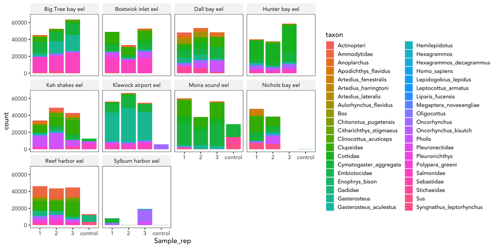

Figure 3: Detection and count of taxon across the eelgrass sites where we have eDNA data and includes controls. This sums across technical replicates

## P/A Heatmap

If we look at this in P/A heatmap style

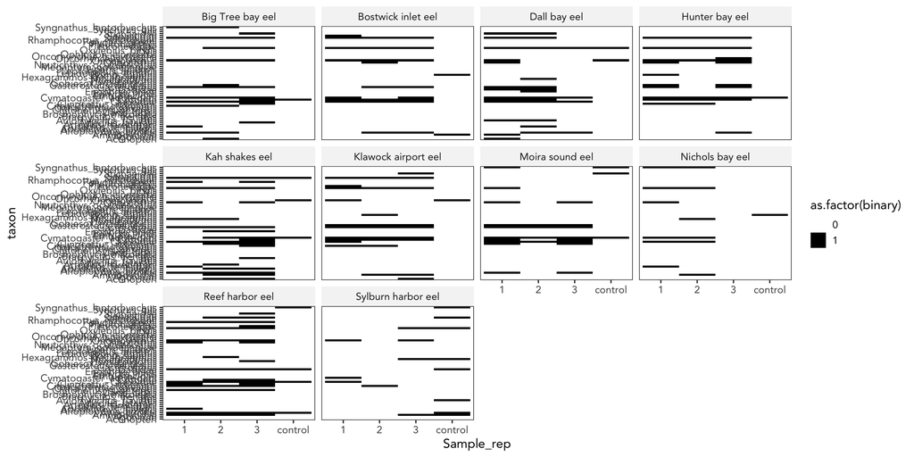

Figure 4: Heat map of the presence/absence of taxon present in eelgrass meadows.

This isn’t that helpful especially since the taxon are hard to read, we need to do a couple things : - combine species that are in the same group (so Oncorhynchus should be combined with species specific instances of Oncorhynchus)

- combine across replicates

```r
unique(edna.hab.long$taxon)
```

```
##  [1] "Pholis"                     "Oncorhynchus"
##  [3] "Salmonidae"                 "Cymatogaster_aggregata"
##  [5] "Clupeidae"                  "Citharichthys_stigmaeus"
##  [7] "Ammodytidae"                "Oligocottus"
##  [9] "Hexagrammos"                "Syngnathus_leptorhynchus"
## [11] "Cottidae"                   "Anoplarchus"
## [13] "Stichaeidae"                "Homo_sapiens"
## [15] "Aulorhynchus_flavidus"      "Gadidae"
## [17] "Bos"                        "Sebastidae"
## [19] "Clinocottus_acuticeps"      "Apodichthys_flavidus"
## [21] "Enophrys_bison"             "Actinopteri"
## [23] "Polypera_greeni"            "Hemilepidotus"
## [25] "Chitonotus_pugetensis"      "Pleuronectidae"
## [27] "Hexagrammos_decagrammus"    "Gasterosteus"
## [29] "Gobiesox_maeandricus"       "Artedius_lateralis"
## [31] "Canis_lupus"                "Artedius_fenestralis"
## [33] "Artedius_harringtoni"       "Sus"
## [35] "Anoplopoma_fimbria"         "Oxylebius_pictus"
## [37] "Rhamphocottus_richardsonii" "Oncorhynchus_tshawytscha"
## [39] "Nautichthys_oculofasciatus" "Gasterosteus_aculeatus"
## [41] "Lepidogobius_lepidus"       "Liparis_fucensis"
## [43] "Brachyistius_frenatus"      "Megaptera_novaeangliae"
## [45] "Embiotocidae"               "Ovis"
## [47] "Synchirus_gilli"            "Ophiodon_elongatus"
## [49] "Pleuronichthys"             "Enhydra_lutris"
## [51] "Oncorhynchus_kisutch"       "Citharichthys_sordidus"
## [53] "Brosmophycis_marginata"     "Leptocottus_armatus"
## [55] "Agonidae"
```

```r
edna.hab.long$taxon <- as.factor(edna.hab.long$taxon)

levels(edna.hab.long$taxon)[levels(edna.hab.long$taxon)=="Oncorhynchus_kisutch"] <- "Oncorhynchus"
levels(edna.hab.long$taxon)[levels(edna.hab.long$taxon)=="Hexagrammos_decagrammus"] <- "Hexagrammos"
levels(edna.hab.long$taxon)[levels(edna.hab.long$taxon)=="Gasterosteus_aculeatus"] <- "Gasterosteus"
levels(edna.hab.long$taxon)[levels(edna.hab.long$taxon)=="Oncorhynchus_tshawytscha"] <- "Oncorhynchus"
# Oligocottus genus of sculpins
# Cottidae family of sculpins
# Anoplarchus genus of cockscombs
# Stichaeidae family of pricklebacks
# Apodichthys_flavidus penpoint gunnel
# Actinopteri - class of ray finned fishes general
# Polypera_greeni Lopefine snailfish
# Hemilepidotus - genus of sclupins (irish lords)
# Pleuronectidae family of right eye flounders
  # Pleuronectidae is a genus within this family
# Gobiesox_maeandricus - northern clingfish
# Oxylebius_pictus painted greenling
# Nautichthys_oculofasciatus - sailfin sculpin
# Ophiodon_elongatus lingcod

# filter out canis_lupus, homo_sapiens, megapstera_novaeangliae, enhydra_lutris, Genus Sus (domestic pig), Genus Bos (beef),
# Genus Ovis (lamb)
edna.fish.long <- edna.hab.long %>%
  filter(taxon != "Canis_lupus" & taxon != "Homo_sapiens" & taxon != "Megaptera_novaeangliae" &
           taxon != "Enhydra_lutris" & taxon != "Sus" & taxon != "Bos" & taxon != "Ovis")

unique(edna.fish.long$taxon) # now 51 unique occurrences
```

```
##  [1] Pholis                     Oncorhynchus
##  [3] Salmonidae                 Cymatogaster_aggregata
##  [5] Clupeidae                  Citharichthys_stigmaeus
##  [7] Ammodytidae                Oligocottus
##  [9] Hexagrammos                Syngnathus_leptorhynchus
## [11] Cottidae                   Anoplarchus
## [13] Stichaeidae                Aulorhynchus_flavidus
## [15] Gadidae                    Sebastidae
## [17] Clinocottus_acuticeps      Apodichthys_flavidus
## [19] Enophrys_bison             Actinopteri
## [21] Polypera_greeni            Hemilepidotus
## [23] Chitonotus_pugetensis      Pleuronectidae
## [25] Gasterosteus               Gobiesox_maeandricus
## [27] Artedius_lateralis         Artedius_fenestralis
## [29] Artedius_harringtoni       Anoplopoma_fimbria
## [31] Oxylebius_pictus           Rhamphocottus_richardsonii
## [33] Nautichthys_oculofasciatus Lepidogobius_lepidus
## [35] Liparis_fucensis           Brachyistius_frenatus
## [37] Embiotocidae               Synchirus_gilli
## [39] Ophiodon_elongatus         Pleuronichthys
## [41] Citharichthys_sordidus     Brosmophycis_marginata
## [43] Leptocottus_armatus        Agonidae
## 51 Levels: Actinopteri Agonidae Ammodytidae Anoplarchus ... Syngnathus_leptorhynchus
```

```r
edna.fish.long$taxon <- as.character(edna.fish.long$taxon)

# need to combine the presence/absence with the renaming of the levels of taxon
edna.fish.long <- distinct(edna.fish.long)
```

## reduced species in eelgrass

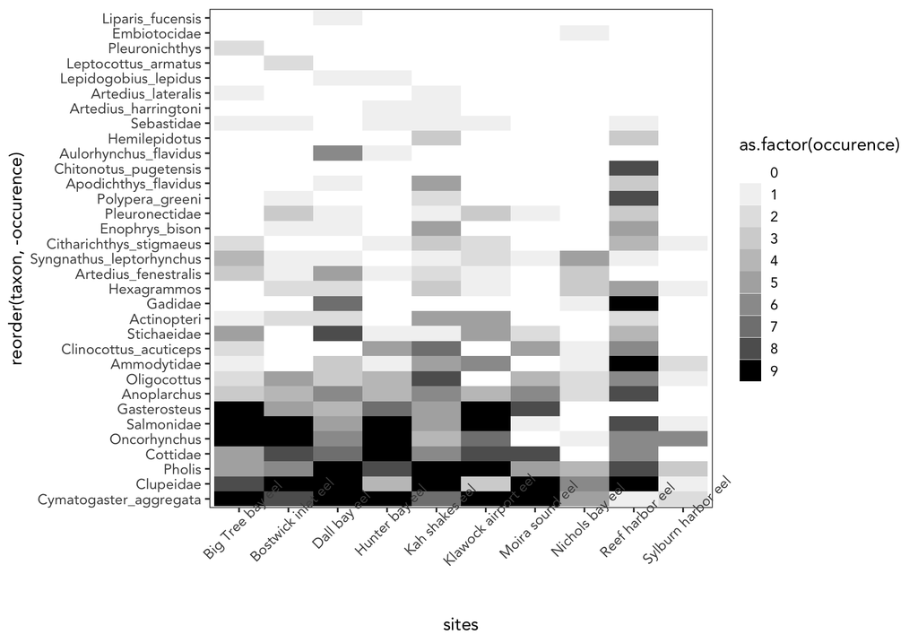

```r
# this includes the control in the counts so its not right, need to remove the control, then summarize, add control back in, and graph
# remove control binary and taxon at sites
control.eel <- edna.fish.long %>%
  filter(habitat == "eelgrass" & Sample_rep == "control") %>%
  distinct()

# creates list of fish species without any occurrences
no.occ.eel <- edna.fish.long %>%
  filter(habitat == "eelgrass" & Sample_rep != "control") %>%
  group_by(taxon) %>%
  dplyr::summarise(occurrence = sum(binary)) %>%
  subset(occurrence == "0") %>%
  dplyr::select(-occurrence)

#no.occ.eel <- as.vector(no.occ$taxon)
```

Looking at this graph, what is the most useful about it? This doesn’t subtract out the field controls. Based on some conversations with Pat Berry we can try and subtract the ASVs counts in the control from (each? I think) each field sample. This should be done on the basis of the ASV - not the species identification.

This graph is a combination of the field and lab replicates. I think about the lab replicates as an expression of the stochasicity present in each field replicate – so in my ideal world I would express each field replicate individually plus or minus some certainty. However, since this data is binary this doesn’t make sense. Instead maybe re-graph each field replicate with occurrence (0-3) based on the lab replciates

# understory kelp combined tech replicates

## reduced species in kelp heatmap

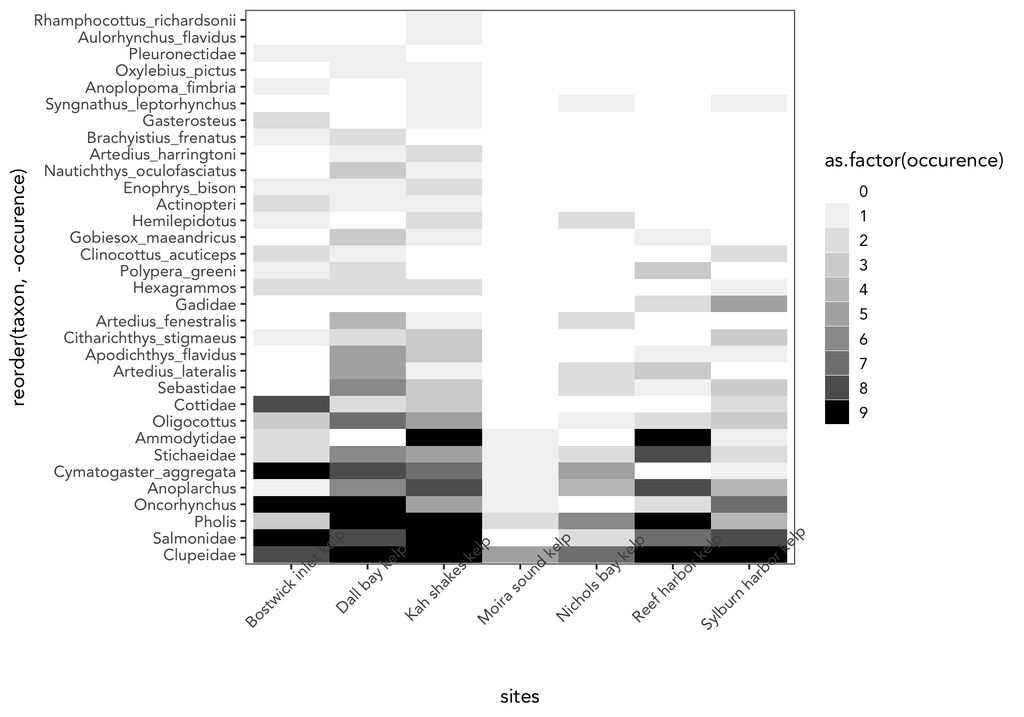

```r
# this includes the control in the counts so its not right, need to remove the control, then summarize, add control back in, and graph
# remove control binary and taxon at sites
control.kelp <- edna.fish.long %>%
  filter(habitat == "kelp" & Sample_rep == "control") %>%
  distinct()

# creates list of fish species without any occurrences
no.occ.kelp <- edna.fish.long %>%
  filter(habitat == "kelp" & Sample_rep != "control") %>%
  group_by(taxon) %>%
  dplyr::summarise(occurrence = sum(binary)) %>%
  subset(occurrence == "0") %>%
  dplyr::select(-occurrence)
```

### explanation of some of the species or species group present in the graphs above

- Oligocottus genus of sculpins
- Cottidae family of sculpins
- Anoplarchus genus of cockscombs
- Stichaeidae family of pricklebacks
- Apodichthys_flavidus penpoint gunnel
- Actinopteri - class of ray finned fishes general
- Polypera_greeni Lopefine snailfish
- Hemilepidotus - genus of sclupins (irish lords)
- Pleuronectidae family of right eye flounders
- Pleuronectidae is a genus within this family
- Gobiesox_maeandricus - northern clingfish
- Oxylebius_pictus painted greenling
- Nautichthys_oculofasciatus - sailfin sculpin
- Ophiodon_elongatus lingcod

# Accounting for field controls

In the taxonomic filtering edna 2021 RMD script, I subtracted the counts in the controls (summed across lab replicates) from each field replicate

**This does not include the negative and positive controls (or even the DNA extraction controls)**

```r
# data without the control
glimpse(minuscontrol.long.counts)
```

```
## Rows: 9,342
## Columns: 10
## $ sites                 <chr> "Sylburn harbor eel", "Sylburn harbor eel", "Syl…
## $ habitat               <chr> "eelgrass", "eelgrass", "eelgrass", "eelgrass", …
## $ sample.PCR            <chr> "e00289-A", "e00289-A", "e00289-A", "e00289-A", …
## $ sample                <chr> "e00289", "e00289", "e00289", "e00289", "e00289"…
## $ SampleCode            <chr> "2021_SYLB_A_1", "2021_SYLB_A_1", "2021_SYLB_A_1…
## $ Sample_rep            <int> 1, 1, 1, 1, 1, 1, 1, 1, 1, 1, 1, 1, 1, 1, 1, 1, …
## $ Sample_date           <chr> "6/8/21", "6/8/21", "6/8/21", "6/8/21", "6/8/21"…
## $ Extraction_date       <chr> "11/18/21", "11/18/21", "11/18/21", "11/18/21", …
## $ taxon                 <chr> "Pholis", "Oncorhynchus", "Salmonidae", "Cymatog…
## $ counts_minus_controls <int> 0, 1110, 0, 0, 0, 0, 0, 0, 0, 0, 0, 0, 0, 0, 0, …
```

```r
glimpse(minuscontrol.long.bin)
```

```
## Rows: 9,342
## Columns: 10
## $ sites           <chr> "Sylburn harbor eel", "Sylburn harbor eel", "Sylburn h…
## $ habitat         <chr> "eelgrass", "eelgrass", "eelgrass", "eelgrass", "eelgr…
## $ sample.PCR      <chr> "e00289-A", "e00289-A", "e00289-A", "e00289-A", "e0028…
## $ sample          <chr> "e00289", "e00289", "e00289", "e00289", "e00289", "e00…
## $ SampleCode      <chr> "2021_SYLB_A_1", "2021_SYLB_A_1", "2021_SYLB_A_1", "20…
## $ Sample_rep      <int> 1, 1, 1, 1, 1, 1, 1, 1, 1, 1, 1, 1, 1, 1, 1, 1, 1, 1, …
## $ Sample_date     <chr> "6/8/21", "6/8/21", "6/8/21", "6/8/21", "6/8/21", "6/8…
## $ Extraction_date <chr> "11/18/21", "11/18/21", "11/18/21", "11/18/21", "11/18…
## $ taxon           <chr> "Pholis", "Oncorhynchus", "Salmonidae", "Cymatogaster_…
## $ binary          <dbl> 0, 1, 0, 0, 0, 0, 0, 0, 0, 0, 0, 0, 0, 0, 0, 0, 0, 0, …
```

Lets graph by habitat types and summed ASV counts by species ## eelgrass by field_tech reps

```r
minuscontrol.long.counts <- minuscontrol.long.counts %>%
  separate(sample.PCR, into = c("sample.PCR", "rep"), sep = "-", remove = FALSE) %>%
  unite(sample.PCR, sample.PCR:rep, sep = "-", remove = FALSE) # for wahtever reason you have to put it back together to keep column
# repeat with binary
minuscontrol.long.bin <- minuscontrol.long.bin %>%
  separate(sample.PCR, into = c("sample.PCR", "rep"), sep = "-", remove = FALSE) %>%
  unite(sample.PCR, sample.PCR:rep, sep = "-", remove = FALSE) # for wahtever reason you have to put it back together to keep column
```

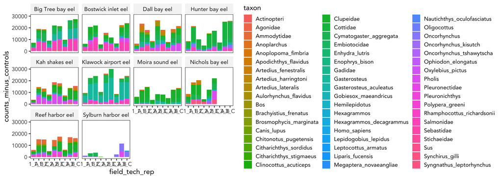

## kelp by field_tech reps

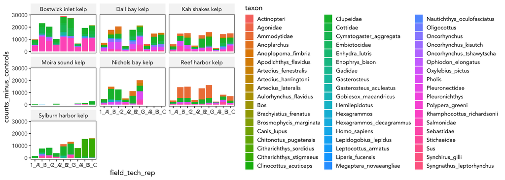

# Reduce/combine species

Combine the salmon species because we know the primer doesn’t do a great job of seperating them This will be for the heat maps with p/a

```r
unique(minuscontrol.long.bin$taxon)
```

```
##  [1] "Pholis"                     "Oncorhynchus"
##  [3] "Salmonidae"                 "Cymatogaster_aggregata"
##  [5] "Clupeidae"                  "Citharichthys_stigmaeus"
##  [7] "Ammodytidae"                "Oligocottus"
##  [9] "Hexagrammos"                "Bos"
## [11] "Syngnathus_leptorhynchus"   "Gadidae"
## [13] "Sebastidae"                 "Stichaeidae"
## [15] "Anoplarchus"                "Cottidae"
## [17] "Clinocottus_acuticeps"      "Apodichthys_flavidus"
## [19] "Enophrys_bison"             "Actinopteri"
## [21] "Polypera_greeni"            "Hemilepidotus"
## [23] "Chitonotus_pugetensis"      "Pleuronectidae"
## [25] "Hexagrammos_decagrammus"    "Gobiesox_maeandricus"
## [27] "Artedius_lateralis"         "Canis_lupus"
## [29] "Gasterosteus"               "Artedius_fenestralis"
## [31] "Artedius_harringtoni"       "Sus"
## [33] "Anoplopoma_fimbria"         "Oxylebius_pictus"
## [35] "Aulorhynchus_flavidus"      "Rhamphocottus_richardsonii"
## [37] "Oncorhynchus_tshawytscha"   "Nautichthys_oculofasciatus"
## [39] "Lepidogobius_lepidus"       "Liparis_fucensis"
## [41] "Brachyistius_frenatus"      "Homo_sapiens"
## [43] "Gasterosteus_aculeatus"     "Megaptera_novaeangliae"
## [45] "Embiotocidae"               "Synchirus_gilli"
## [47] "Ophiodon_elongatus"         "Pleuronichthys"
## [49] "Enhydra_lutris"             "Oncorhynchus_kisutch"
## [51] "Citharichthys_sordidus"     "Brosmophycis_marginata"
## [53] "Leptocottus_armatus"        "Agonidae"
```

```r
minuscontrol.long.bin$taxon <- as.factor(minuscontrol.long.bin$taxon)

levels(minuscontrol.long.bin$taxon)[levels(minuscontrol.long.bin$taxon)=="Oncorhynchus_kisutch"] <- "Oncorhynchus"
levels(minuscontrol.long.bin$taxon)[levels(minuscontrol.long.bin$taxon)=="Hexagrammos_decagrammus"] <- "Hexagrammos"
levels(minuscontrol.long.bin$taxon)[levels(minuscontrol.long.bin$taxon)=="Gasterosteus_aculeatus"] <- "Gasterosteus"
levels(minuscontrol.long.bin$taxon)[levels(minuscontrol.long.bin$taxon)=="Oncorhynchus_tshawytscha"] <- "Oncorhynchus"
# Oligocottus genus of sculpins
# Cottidae family of sculpins
# Anoplarchus genus of cockscombs
# Stichaeidae family of pricklebacks
# Apodichthys_flavidus penpoint gunnel
# Actinopteri - class of ray finned fishes general
# Polypera_greeni Lopefine snailfish
# Hemilepidotus - genus of sclupins (irish lords)
# Pleuronectidae family of right eye flounders
  # Pleuronectidae is a genus within this family
# Gobiesox_maeandricus - northern clingfish
# Oxylebius_pictus painted greenling
# Nautichthys_oculofasciatus - sailfin sculpin
# Ophiodon_elongatus lingcod

# filter out canis_lupus, homo_sapiens, megapstera_novaeangliae, enhydra_lutris, Genus Sus (domestic pig), Genus Bos (beef),
# Genus Ovis (lamb)
edna.fish.long.bin <- minuscontrol.long.bin %>%
  filter(taxon != "Canis_lupus" & taxon != "Homo_sapiens" &
            taxon != "Sus" & taxon != "Bos" & taxon != "Ovis")

unique(edna.fish.long.bin$taxon) # now 46 unique occurrences
```

```
##  [1] Pholis                     Oncorhynchus
##  [3] Salmonidae                 Cymatogaster_aggregata
##  [5] Clupeidae                  Citharichthys_stigmaeus
##  [7] Ammodytidae                Oligocottus
##  [9] Hexagrammos                Syngnathus_leptorhynchus
## [11] Gadidae                    Sebastidae
## [13] Stichaeidae                Anoplarchus
## [15] Cottidae                   Clinocottus_acuticeps
## [17] Apodichthys_flavidus       Enophrys_bison
## [19] Actinopteri                Polypera_greeni
## [21] Hemilepidotus              Chitonotus_pugetensis
## [23] Pleuronectidae             Gobiesox_maeandricus
## [25] Artedius_lateralis         Gasterosteus
## [27] Artedius_fenestralis       Artedius_harringtoni
## [29] Anoplopoma_fimbria         Oxylebius_pictus
## [31] Aulorhynchus_flavidus      Rhamphocottus_richardsonii
## [33] Nautichthys_oculofasciatus Lepidogobius_lepidus
## [35] Liparis_fucensis           Brachyistius_frenatus
## [37] Megaptera_novaeangliae     Embiotocidae
## [39] Synchirus_gilli            Ophiodon_elongatus
## [41] Pleuronichthys             Enhydra_lutris
## [43] Citharichthys_sordidus     Brosmophycis_marginata
## [45] Leptocottus_armatus        Agonidae
## 50 Levels: Actinopteri Agonidae Ammodytidae Anoplarchus ... Syngnathus_leptorhynchus
```

```r
edna.fish.long.bin$taxon <- as.character(edna.fish.long.bin$taxon)

# need to combine the presence/absence with the renaming of the levels of taxon
edna.fish.long.bin <- distinct(edna.fish.long.bin)
```

## Reduced species in eelgrass (subtracted control)

```r
# creates list of fish species without any occurrences
no.occ.eel2 <- edna.fish.long.bin %>%
  filter(habitat == "eelgrass" & Sample_rep != "control") %>%
  group_by(taxon) %>%
  dplyr::summarise(occurrence = sum(binary)) %>%
  subset(occurrence == "0") %>%
  dplyr::select(-occurrence)

# which ones are excluded?
no.occ.eel2
```

```
## # A tibble: 12 × 1
##    taxon
##    <chr>
##  1 Agonidae
##  2 Anoplopoma_fimbria
##  3 Brachyistius_frenatus
##  4 Brosmophycis_marginata
##  5 Citharichthys_sordidus
##  6 Enhydra_lutris
##  7 Gobiesox_maeandricus
##  8 Nautichthys_oculofasciatus
##  9 Ophiodon_elongatus
## 10 Oxylebius_pictus
## 11 Rhamphocottus_richardsonii
## 12 Synchirus_gilli
```

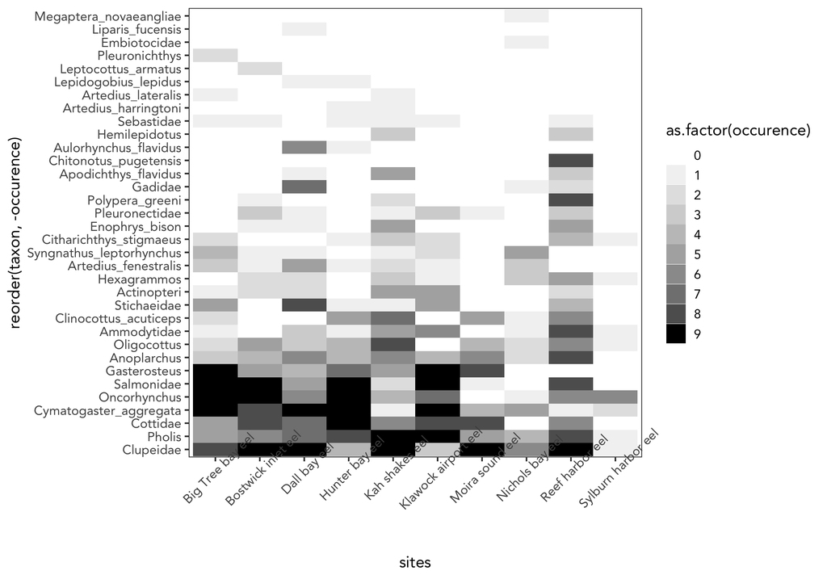

Figure 9: Heat map of the presence/absence of taxon present in eelgrass meadows after subtracting the ASV counts present in the controls and reducing/combining similar or unrealiby primed species

## reduced species in kelp (subtracted control)

```r
# creates list of fish species without any occurrences
no.occ.kelp2 <- edna.fish.long.bin %>%
  filter(habitat == "kelp" & Sample_rep != "control") %>%
  group_by(taxon) %>%
  dplyr::summarise(occurrence = sum(binary)) %>%
  subset(occurrence == "0") %>%
  dplyr::select(-occurrence)

# which ones are excluded?
no.occ.kelp2
```

```
## # A tibble: 13 × 1
##    taxon
##    <chr>
##  1 Agonidae
##  2 Brosmophycis_marginata
##  3 Chitonotus_pugetensis
##  4 Citharichthys_sordidus
##  5 Embiotocidae
##  6 Enhydra_lutris
##  7 Lepidogobius_lepidus
##  8 Leptocottus_armatus
##  9 Liparis_fucensis
## 10 Megaptera_novaeangliae
## 11 Ophiodon_elongatus
## 12 Pleuronichthys
## 13 Synchirus_gilli
```

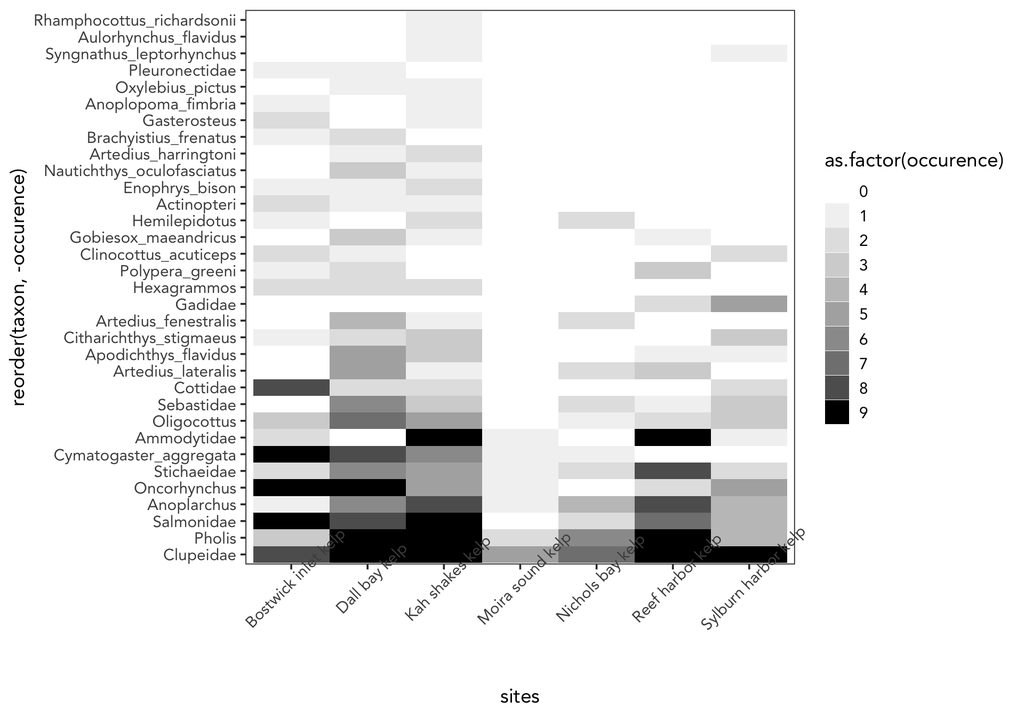

Figure 10: Heat map of the presence/absence of taxon present in understory kelp after subtracting the ASV counts present in the controls and reducing/combining similar or unrealiby primed species

## compare the mixed versus eelgrass habitat

```r
unique(edna.fish.long.bin$habitat)
```

```
## [1] "eelgrass"       "kelp"           "mixed eelgrass"
```

```r
no.occ.eel3 <- edna.fish.long.bin %>%
  filter(sites == "Big Tree bay eel" | sites == "Clam island mixed" | sites == "Cole island mixed" |
         sites == "Hunter bay eel" | sites == "Klawock airport eel" | sites == "Tah bay eel" & Sample_rep != "control") %>%
  group_by(taxon) %>%
  dplyr::summarise(occurrence = sum(binary)) %>%
  subset(occurrence == "0") %>%
  dplyr::select(-occurrence)

# which ones are excluded?
no.occ.eel3
```

```
## # A tibble: 10 × 1
##    taxon
##    <chr>
##  1 Anoplopoma_fimbria
##  2 Chitonotus_pugetensis
##  3 Embiotocidae
##  4 Gobiesox_maeandricus
##  5 Liparis_fucensis
##  6 Megaptera_novaeangliae
##  7 Nautichthys_oculofasciatus
##  8 Oxylebius_pictus
##  9 Polypera_greeni
## 10 Rhamphocottus_richardsonii
```

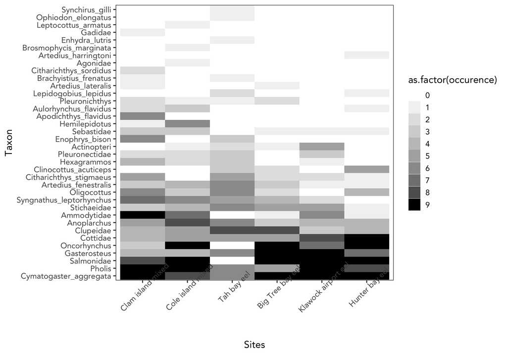

Figure 11: Heat map of the presence/absence of taxon present in eelgrass or mixed eelgrass habitats after subtracting the ASV counts present in the controls and reducing/combining similar or unrealiby primed species

# 2. Community level analysis

Okay so based on the graphs and exploration above, I’m going to use the dataframe that has the control samples subtracted by ASV from the field replicates. I have a couple goals for this section:

2.1 Explore community composition using multivariate approaches between eelgrass and understory kelp eDNA samples

2.2 Explore community composition using MV approaches between eelgrass and mixed eelgrass habitat

2.3 Add in associated beach seine data for the sites where its present

```
2.3.1 Compare within habitat community by beach seine and eelgrass (can this only be done using P/A for beach seine?)
```

Lets start with exploring the MV approaches with the eDNA samples

## Pivot data wide

This is done at the site field replicate level (edna.bin.sp) and keeping the field and lab replicate as unique rows (edna.bin.samplecode_rep2). The rep2 drops four instances that have no genetic fish material.

```r
# first lets take the df that we've cleaned up (no Bos etc in it) and turn it wide
edna.fish.wide <- edna.fish.long.bin %>%
  separate(sample.PCR, into = c("sample.PCR", "rep"), sep = "-", remove = FALSE) %>%
  unite(sample.PCR, sample.PCR:rep, sep = "-", remove = FALSE) %>%
  unite(SampleCode_rep, c(SampleCode, rep)) %>%
  group_by(SampleCode_rep, taxon) %>%
  #summarize(counts = sum(binary)) %>%
  #ungroup() %>%
  #mutate(binary = ifelse(counts > 0, 1, 0)) %>%
  pivot_wider(names_from = taxon,
            values_from = binary, values_fn = sum) # values_fn = sum required because when we changed some levels of the taxon, there were repeat entries for unique rows (i.e. two entries for Oncorhyncus for e00289_A aka Sylburn_A_1_A). The sum adds them up so if it was 0,0 = 0 or 0,1 = 1. Have to check for instances of 1,1 = 2 cause that wont be valid in a binary form.

# above is by sample field replicate combining all tech replicates

# do this only if you're summarizing to field rep (no lab rep)
edna.bin.sp <- edna.fish.long.bin %>%
  group_by(SampleCode, taxon) %>%
  summarize(counts = sum(binary)) %>%
  ungroup() %>%
  mutate(binary = ifelse(counts > 0, 1, 0)) %>%
  pivot_wider(names_from = taxon, id_cols = -counts,
            values_from = binary, values_fn = sum) %>%
  distinct() %>%
  column_to_rownames(var = "SampleCode")
# for field and tech reps
edna.bin.samplecode_rep <- edna.fish.wide %>%
  dplyr::select(c(SampleCode_rep, Pholis:Agonidae)) %>%
  column_to_rownames(var = "SampleCode_rep")

# are there are field/lab rep combinations where no species were found?
sites_wo_reads <- edna.bin.samplecode_rep %>%
  rownames_to_column(var = "SampleCode_rep") %>%
  mutate(total = rowSums(select(., Pholis:Agonidae)))

# there are four sites/reps where no species were found
no_reads <- sites_wo_reads %>%
  filter(total == 0) %>%
  dplyr::select(SampleCode_rep)

edna.bin.samplecode_rep2 <- edna.bin.samplecode_rep %>%
  rownames_to_column(var = "SampleCode_rep") %>%
  anti_join(no_reads, by = c("SampleCode_rep")) %>%
  column_to_rownames(var = "SampleCode_rep")
```

Extract just the site info

```r
# site information
# separate the site information and the unnecessary columns
site.info.byrep <- edna.fish.wide %>%
  anti_join(no_reads, by = "SampleCode_rep") %>%
  dplyr::select(-c(Pholis:Agonidae)) %>%
  distinct()

site.info.bysite <- edna.fish.long.bin %>%
  dplyr::select(-c(sample.PCR, rep, taxon, binary)) %>%
  distinct()
```

## Calculate dissimilarity distances

Focus is using jaccard distances because it works well with binary data and deals appropriate with the double zero issue (in that it doesn’t consider sites that are both **missing** species as more closely related).

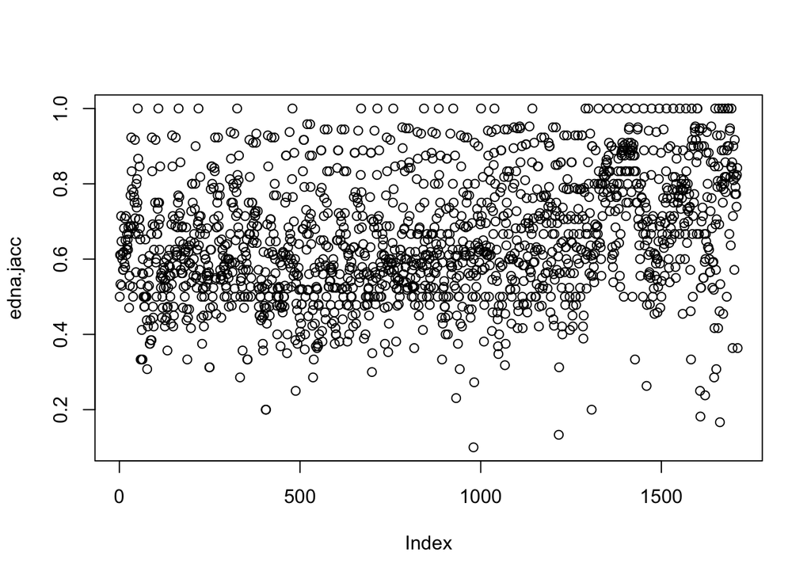

```r
# other binary distance dissimlarities - Dice, kluczynski, ochiai
# jaccard distance
edna.jacc <- vegan::vegdist(edna.bin.sp, method = "jaccard", binary = T)
plot(edna.jacc)
```

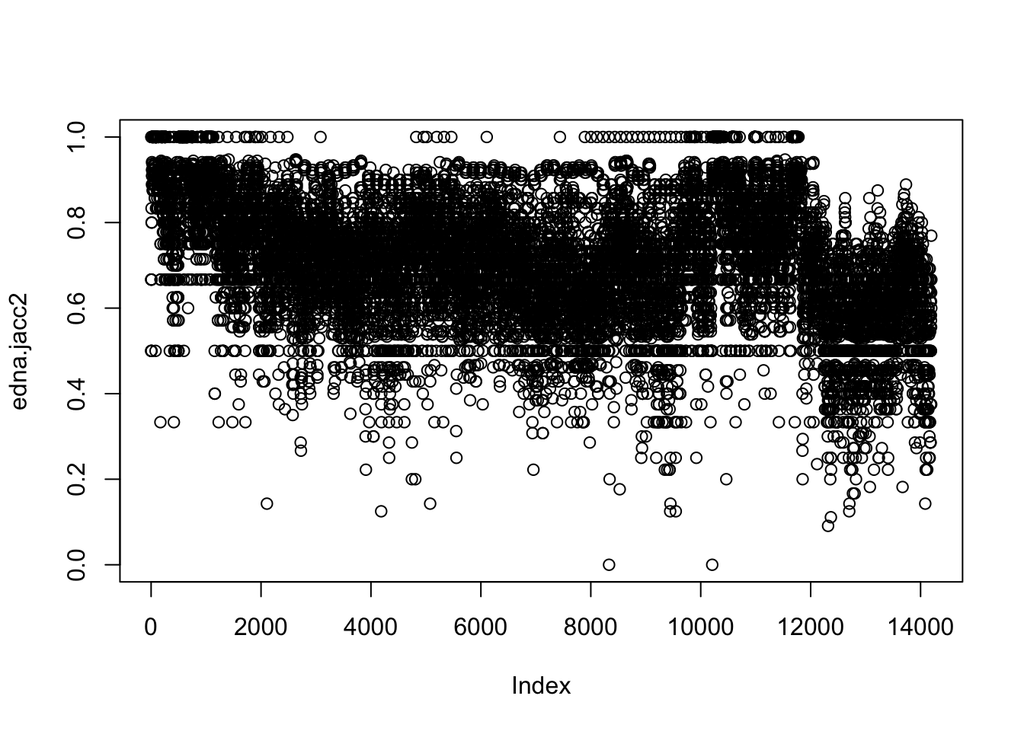

```r
edna.jacc2 <- vegdist(edna.bin.samplecode_rep2, method = "jaccard", binary = T)
plot(edna.jacc2)
```

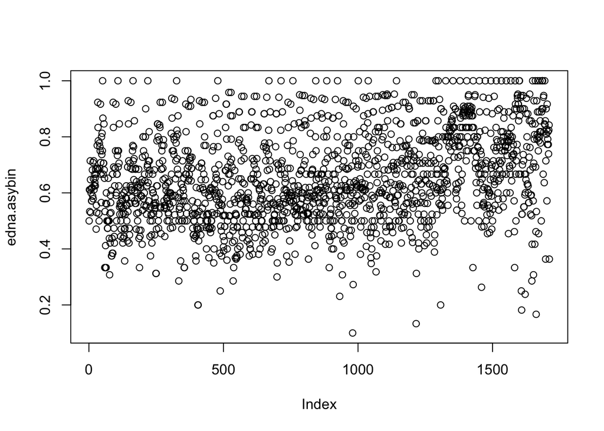

```r
# or using the dist feature
# binary defaults to asymmetric binary, I dont know how this method deals with double zeros
edna.asybin <- dist(edna.bin.sp, method = "binary")
plot(edna.asybin)
```

```r
# what happens when we use bray-curtis dis?
edna.bray <- vegdist(edna.bin.sp, method = "bray")
```

## Test homogeneity of dispersion

randomization test to compare within-group ‘dispersions’ with any distance measure. This tells you if the differences between sites are because of dispersion or variation or if it truly driven by a difference in sites (as can be determined by a PERMANOVA test)

H0 = within-group dispersion have no significant differences.

```r
disp.hab <- betadisper(edna.jacc, site.info.bysite$habitat)
anova(disp.hab) # no within group dispersion by habitat
```

```
## Analysis of Variance Table
##
## Response: Distances
##           Df  Sum Sq  Mean Sq F value Pr(>F)
## Groups     2 0.02136 0.010682  0.5701 0.5687
## Residuals 56 1.04930 0.018737
```

```r
disp.sites <- betadisper(edna.jacc, site.info.bysite$sites)
anova(disp.sites)
```

```
## Analysis of Variance Table
##
## Response: Distances
##           Df  Sum Sq  Mean Sq F value Pr(>F)
## Groups    19 0.65826 0.034645  1.4316 0.1683
## Residuals 39 0.94380 0.024200
```

```r
# there is a difference of dispersion between habitat types (eel, mixed eel, and kelp)
adonis2(edna.jacc ~ habitat, data = site.info.bysite)
```

```
## Permutation test for adonis under reduced model
## Terms added sequentially (first to last)
## Permutation: free
## Number of permutations: 999
##
## adonis2(formula = edna.jacc ~ habitat, data = site.info.bysite)
##          Df SumOfSqs      R2     F Pr(>F)
## habitat   2   0.7272 0.05539 1.642  0.027 *
## Residual 56  12.4011 0.94461
## Total    58  13.1284 1.00000
## ---
## Signif. codes:  0 '***' 0.001 '**' 0.01 '*' 0.05 '.' 0.1 ' ' 1
```

```r
adonis2(edna.jacc ~ habitat + sites, data = site.info.bysite)
```

```
## Permutation test for adonis under reduced model
## Terms added sequentially (first to last)
## Permutation: free
## Number of permutations: 999
##
## adonis2(formula = edna.jacc ~ habitat + sites, data = site.info.bysite)
##          Df SumOfSqs      R2      F Pr(>F)
## habitat   2   0.7272 0.05539 2.3138  0.002 **
## sites    17   6.2725 0.47778 2.3479  0.001 ***
## Residual 39   6.1287 0.46683
## Total    58  13.1284 1.00000
## ---
## Signif. codes:  0 '***' 0.001 '**' 0.01 '*' 0.05 '.' 0.1 ' ' 1
```

```r
adonis2(edna.jacc ~ sites + Sample_rep, data = site.info.bysite)
```

```
## Permutation test for adonis under reduced model
## Terms added sequentially (first to last)
## Permutation: free
## Number of permutations: 999
##
## adonis2(formula = edna.jacc ~ sites + Sample_rep, data = site.info.bysite)
##            Df SumOfSqs      R2      F Pr(>F)
## sites      19   6.9997 0.53317 2.3194  0.001 ***
## Sample_rep  1   0.0929 0.00708 0.5850  0.905
## Residual   38   6.0358 0.45975
## Total      58  13.1284 1.00000
## ---
## Signif. codes:  0 '***' 0.001 '**' 0.01 '*' 0.05 '.' 0.1 ' ' 1
```

```r
# okays os there's a lot of variability even between unique sites, but at least there isn't signifcant variation between field replciates....

disp.hab2 <- betadisper(edna.jacc2, site.info.byrep$habitat)
anova(disp.hab2) # no within group dispersion by hab any permanova analysis will be accurate
```

```
## Analysis of Variance Table
##
## Response: Distances
##            Df Sum Sq  Mean Sq F value Pr(>F)
## Groups      2 0.0361 0.018052  1.3921 0.2514
## Residuals 166 2.1526 0.012967
```

```r
adonis2(edna.jacc2 ~ habitat, data = site.info.byrep) # true diff between habitat types
```

```
## Permutation test for adonis under reduced model
## Terms added sequentially (first to last)
## Permutation: free
## Number of permutations: 999
##
## adonis2(formula = edna.jacc2 ~ habitat, data = site.info.byrep)
##           Df SumOfSqs      R2      F Pr(>F)
## habitat    2    3.293 0.07485 6.7157  0.001 ***
## Residual 166   40.705 0.92515
## Total    168   43.998 1.00000
## ---
## Signif. codes:  0 '***' 0.001 '**' 0.01 '*' 0.05 '.' 0.1 ' ' 1
```

## NMDS

Brief foray into nmds - Do I think metric or non-metric more appropriate for this kind of data?

```r
edna.nmds <- metaMDS(edna.jacc2, k = 3, autotransform = FALSE, distance = "jaccard",
                     maxit = 200000)
```

```
## *** No convergence -- monoMDS stopping criteria:
##     20: stress ratio > sratmax
```

```r
# with only 2 dimensions, the nmds didn't coverge and had stress over 20%
edna.nmds$stress
```

```
## [1] 0.175494
```

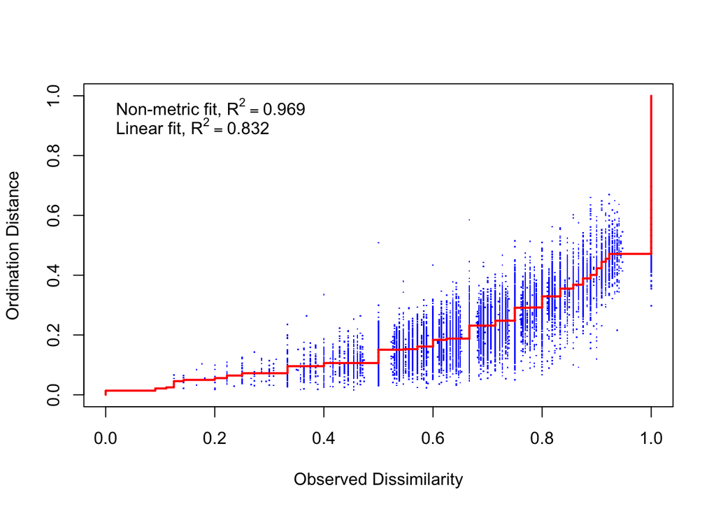

```r
# with three dimensions
stressplot(edna.nmds) # this is with 3 dimension, 17% which is okay.
```

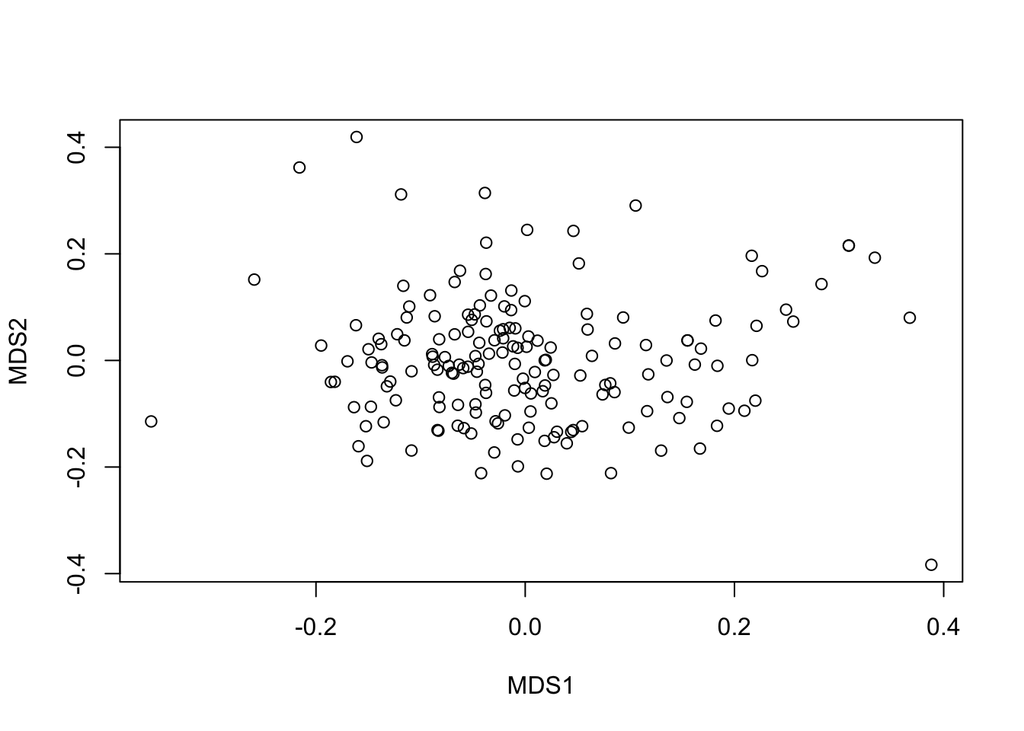

```r
plot(edna.nmds$points)
```

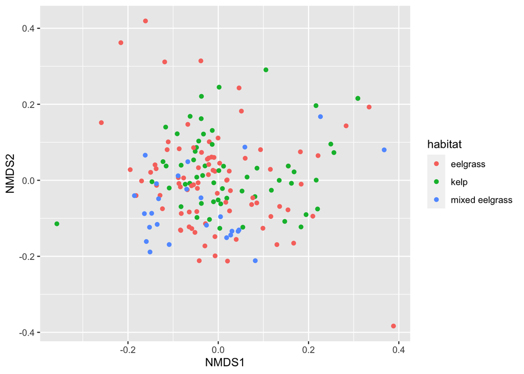

```r
scores(edna.nmds) %>%
  as_tibble(rownames = "SampleCode_rep") %>%
  inner_join(site.info.byrep) %>%
  ggplot(aes(x = NMDS1, y = NMDS2, color = habitat)) +
  geom_point()
```

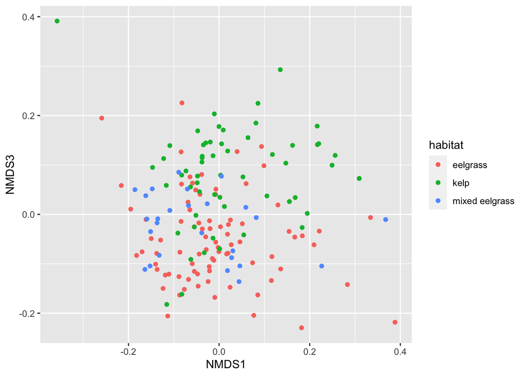

```r
scores(edna.nmds) %>%
  as_tibble(rownames = "SampleCode_rep") %>%
  inner_join(site.info.byrep) %>%
  ggplot(aes(x = NMDS1, y = NMDS3, color = habitat)) +
  geom_point()
```

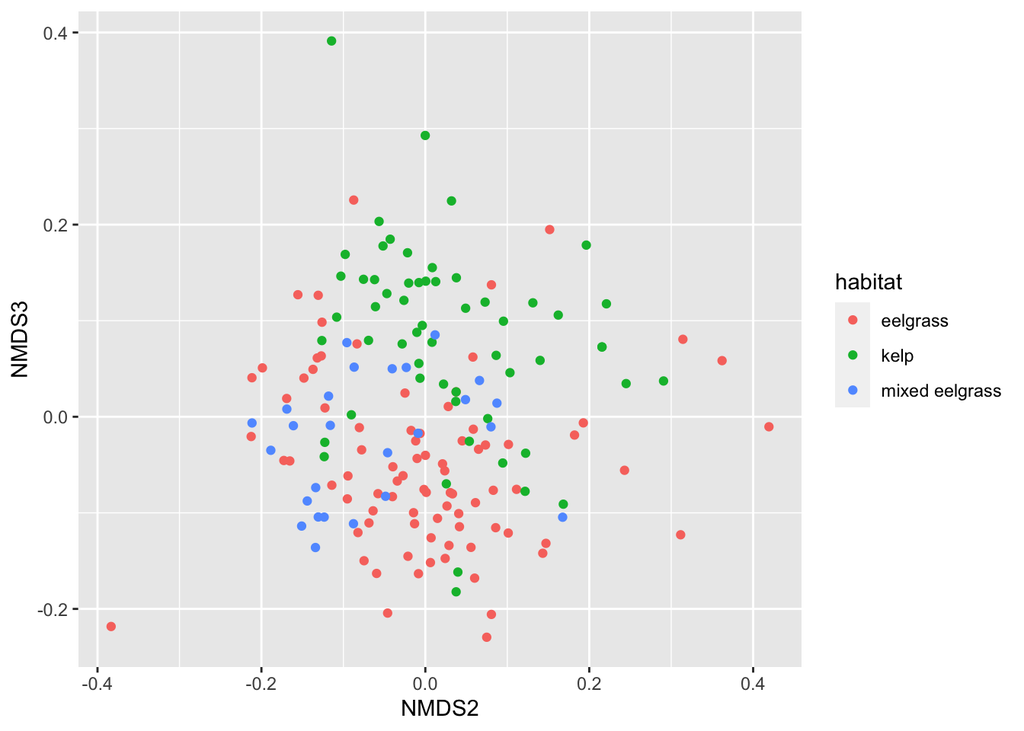

```r
scores(edna.nmds) %>%
  as_tibble(rownames = "SampleCode_rep") %>%
  inner_join(site.info.byrep) %>%
  ggplot(aes(x = NMDS2, y = NMDS3, color = habitat)) +
  geom_point()
```

Because its three dimensions, you need three nmds biplots to show all the data.

## PCoA

metric dimensional scaling - principal coordinates analysis

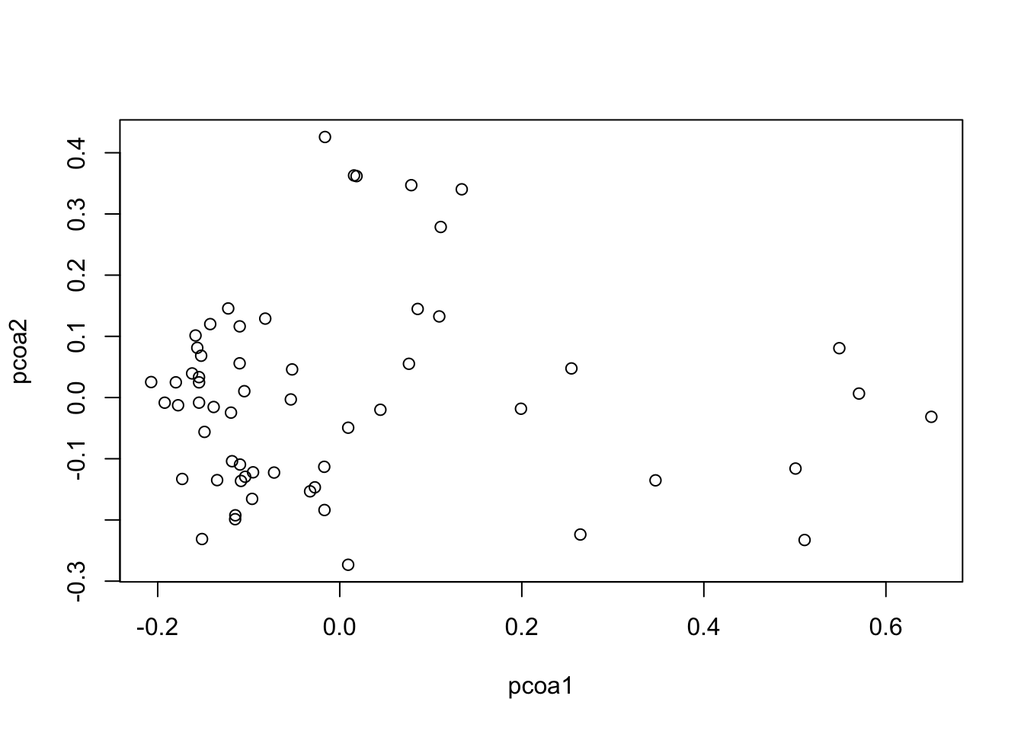

```r
## trying pco or pcoa instead
pco.jacc <- cmdscale(edna.jacc)
colnames(pco.jacc) <- c("pcoa1", "pcoa2")

plot(pco.jacc)
```

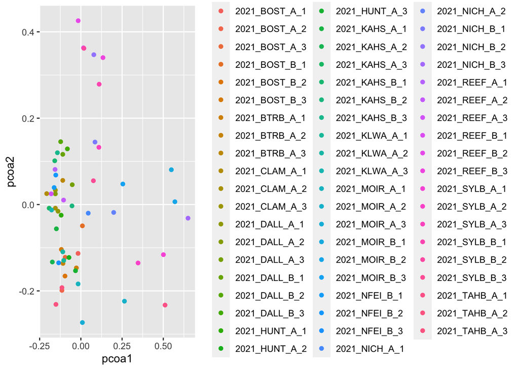

```r
pco.jacc %>%
  as_tibble(rownames = "site_rep") %>%
  ggplot(aes(x = pcoa1, y = pcoa2, color = site_rep)) +
  geom_point()
```

```r
# with by the site/lab rep
pco.jacc2 <- cmdscale(edna.jacc2, k = 2, eig = T, add = T)
colnames(pco.jacc2$points) <- c("pcoa1", "pcoa2")
# eiganvector - positions on the x and y axis (points)
# eiganvalues - indicate something about the proportion of the variation explained by the different axis. So we can use eiganvalues to get porpotion explained. Some of these eiganvalues are negative. Need to be rescaled (this is done by add = T)

# eiganvalue
pco.jacc2$eig # the % explained by axis 1 is the first value divided by the total of all the eiganvalues *100
```

```
##   [1]  9.418245e+00  7.687394e+00  6.284328e+00  4.781093e+00  4.398711e+00
##   [6]  4.384938e+00  3.834233e+00  3.319092e+00  3.054937e+00  2.827401e+00
##  [11]  2.666692e+00  2.460855e+00  2.223211e+00  2.070871e+00  1.840878e+00
##  [16]  1.689431e+00  1.651851e+00  1.521307e+00  1.321083e+00  1.255723e+00
##  [21]  1.161111e+00  1.127508e+00  1.032665e+00  1.008386e+00  9.221189e-01
##  [26]  8.561499e-01  7.912092e-01  7.032651e-01  5.861598e-01  5.454818e-01
##  [31]  4.759691e-01  4.578212e-01  4.439191e-01  4.235516e-01  3.900656e-01
##  [36]  3.768421e-01  3.731324e-01  3.076674e-01  2.912490e-01  2.738480e-01
##  [41]  2.668085e-01  2.538221e-01  2.458901e-01  2.245208e-01  2.122595e-01
##  [46]  1.947158e-01  1.818588e-01  1.762876e-01  1.695476e-01  1.656267e-01
##  [51]  1.654952e-01  1.610277e-01  1.504242e-01  1.459950e-01  1.451106e-01
##  [56]  1.339770e-01  1.287957e-01  1.255183e-01  1.218540e-01  1.152893e-01
##  [61]  1.127251e-01  1.071096e-01  1.040992e-01  9.930245e-02  9.781347e-02
##  [66]  9.220409e-02  8.860783e-02  8.535887e-02  8.430047e-02  8.128271e-02
##  [71]  7.874789e-02  7.687874e-02  7.432777e-02  7.151337e-02  7.096586e-02
```

[output cut: 19 more lines]

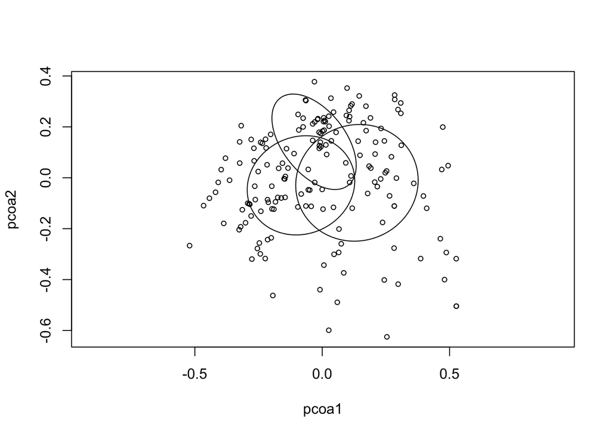

```r
percent_explained <- 100* pco.jacc2$eig/ sum(pco.jacc2$eig)
pe <- format(round(percent_explained[1:2], digits = 1), nsmall = 1, trim = T)

labs <- c(glue("PCoA 1 ({pe[1]}%)"),
          glue("PcoA 2 ({pe[2]}%)"))

ordiplot(pco.jacc2, display = "sites")
ordiellipse(pco.jacc2, site.info.byrep$habitat)
```

## 2.1 Visualize PCoA of eDNA data

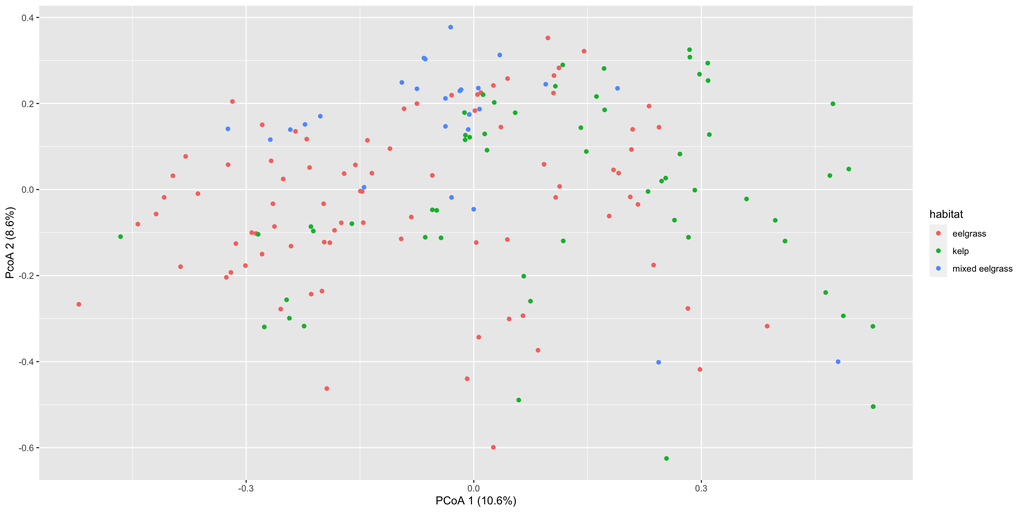

Figure 12: Principal coordinates analysis of the environmental DNA presence/absence data. Each dog represents an individual field sample and technical replicate instance. Points are colored by habitat that they were sampled in

PCoA of all the habitat types: hard to see any clear patterns or clustering of the data points by habitat type. Each point is a unique combination of the field sample plus the lab replicate. So if we sampled 3 times in the field at a site and then did 3 lab replicates of each field sample it means that at each site we have 9 non control samples. However, since not every sample/lab replicate had genetic material in it I have to drop some of those replciates. Overall there were 169 rows of unique site:field rep:tech rep instances that went into the PCoA and distance calculation (using jaccard distances).

Still working on understanding if the same analytical approaches are valid for pcoa based data, but using the beta disper function, I determined that the assumption of homogeneity of variance holds and that the permanova test of habitat found that there are significant differences between fish communities in different habitat.

To see the cumulative increase in variance explained increases with increased number of axes. Percent of the variance explained by each ordination axis when using the principal coordinates analysis.

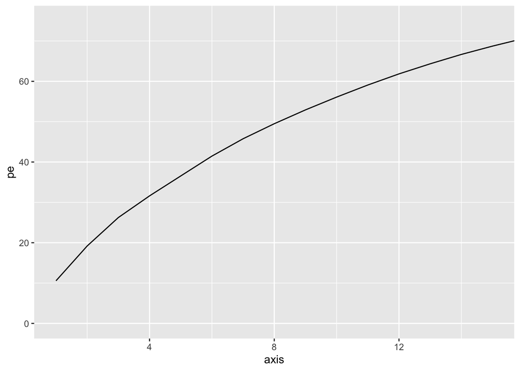

```r
# create scree plot that shows the percent explained
tibble(pe = cumsum(percent_explained),
       axis = 1:length(percent_explained)) %>%
  ggplot(aes(x = axis, y = pe)) +
  geom_line() +
  coord_cartesian(xlim = c(1,15), ylim = c(0, 75))
```

Just under 20% of the variation in the data are explained by the first and second axes of PCoA. This isn’t a ton but kinda to be expected when working with highly variable ecological data. To explain approximately 50% of the variation in the data you would need to visualize the data in 8 dimensions. Which my wee brain can’t comprehend.

## 2.2 Eel and mixed eel - comparison

```r
#head(edna.bin.samplecode_rep2)
head(site.info.byrep)
```

```
## # A tibble: 6 × 8
## # Groups:   SampleCode_rep [6]
##   sites          habitat sample SampleCode_rep sample.PCR Sample_rep Sample_date
##   <chr>          <chr>   <chr>  <chr>          <chr>           <int> <chr>
## 1 Sylburn harbo… eelgra… e00289 2021_SYLB_A_1… e00289-A            1 6/8/21
## 2 Sylburn harbo… eelgra… e00289 2021_SYLB_A_1… e00289-B            1 6/8/21
## 3 Sylburn harbo… eelgra… e00289 2021_SYLB_A_1… e00289-C            1 6/8/21
## 4 Sylburn harbo… eelgra… e00290 2021_SYLB_A_2… e00290-A            2 6/8/21
## 5 Sylburn harbo… eelgra… e00291 2021_SYLB_A_3… e00291-A            3 6/8/21
## 6 Sylburn harbo… eelgra… e00291 2021_SYLB_A_3… e00291-B            3 6/8/21
## # … with 1 more variable: Extraction_date <chr>
```

```r
# subset dataframe to just the eelgrass
eel.samplecode_rep2 <- edna.bin.samplecode_rep2 %>%
  rownames_to_column(var = "SampleCode_rep") %>%
  inner_join(site.info.byrep) %>%
  filter(habitat != "kelp") %>%
  dplyr::select(c(SampleCode_rep, Pholis:Agonidae)) %>%
  column_to_rownames(var = "SampleCode_rep")
# filter the site info too
eel.site.byrep <- site.info.byrep %>%
  filter(habitat != "kelp")

# calculate distance matrix
eel.jacc <- vegdist(eel.samplecode_rep2, method = "jaccard", binary = T)
```

### Test homogeneity of dispersion

randomization test to compare within-group ‘dispersions’ with any distance measure. This tells you if the differences between sites are because of dispersion or variation or if it truly driven by a difference in sites (as can be determined by a PERMANOVA test)

H0 = within-group dispersion have no significant differences.

```r
disp.eel.hab <- betadisper(eel.jacc, eel.site.byrep$habitat)
anova(disp.eel.hab)
```

```
## Analysis of Variance Table
##
## Response: Distances
##            Df  Sum Sq  Mean Sq F value Pr(>F)
## Groups      1 0.02214 0.022136  1.4832 0.2259
## Residuals 109 1.62682 0.014925
```

```r
# no within group dispersion by habitat

adonis2(eel.jacc ~ habitat, data = eel.site.byrep)
```

```
## Permutation test for adonis under reduced model
## Terms added sequentially (first to last)
## Permutation: free
## Number of permutations: 999
##
## adonis2(formula = eel.jacc ~ habitat, data = eel.site.byrep)
##           Df SumOfSqs      R2      F Pr(>F)
## habitat    1   1.0684 0.03913 4.4386  0.001 ***
## Residual 109  26.2373 0.96087
## Total    110  27.3058 1.00000
## ---
## Signif. codes:  0 '***' 0.001 '**' 0.01 '*' 0.05 '.' 0.1 ' ' 1
```

```r
# okay so there are a difference between habitat, but could this just be the fact that these sites are super variable to begin with and this is actually driven by the variation in sites?

# test this
disp.eel.sites <- betadisper(eel.jacc, eel.site.byrep$sites)
anova(disp.eel.sites) # no within sites variability
```

```
## Analysis of Variance Table
##
## Response: Distances
##           Df Sum Sq  Mean Sq F value Pr(>F)
## Groups    12 0.2881 0.024009  1.5255 0.1278
## Residuals 98 1.5423 0.015738
```

```r
adonis2(eel.jacc ~ habitat + sites, data = eel.site.byrep)
```

```
## Permutation test for adonis under reduced model
## Terms added sequentially (first to last)
## Permutation: free
## Number of permutations: 999
##
## adonis2(formula = eel.jacc ~ habitat + sites, data = eel.site.byrep)
##           Df SumOfSqs      R2      F Pr(>F)
## habitat    1   1.0684 0.03913 6.9471  0.001 ***
## sites     11  11.1655 0.40891 6.6000  0.001 ***
## Residual  98  15.0719 0.55197
## Total    110  27.3058 1.00000
## ---
## Signif. codes:  0 '***' 0.001 '**' 0.01 '*' 0.05 '.' 0.1 ' ' 1
```

```r
adonis2(eel.jacc ~ sites, data = eel.site.byrep)
```

```
## Permutation test for adonis under reduced model
## Terms added sequentially (first to last)
## Permutation: free
## Number of permutations: 999
##
## adonis2(formula = eel.jacc ~ sites, data = eel.site.byrep)
##           Df SumOfSqs      R2      F Pr(>F)
## sites     12   12.234 0.44803 6.6289  0.001 ***
## Residual  98   15.072 0.55197
## Total    110   27.306 1.00000
## ---
## Signif. codes:  0 '***' 0.001 '**' 0.01 '*' 0.05 '.' 0.1 ' ' 1
```

```r
# both between group significant difference between sites and habitats.

adonis2(eel.jacc ~ habitat + sites + Sample_rep, data = eel.site.byrep)
```

```
## Permutation test for adonis under reduced model
## Terms added sequentially (first to last)
## Permutation: free
## Number of permutations: 999
##
## adonis2(formula = eel.jacc ~ habitat + sites + Sample_rep, data = eel.site.byrep)
##             Df SumOfSqs      R2      F Pr(>F)
## habitat      1   1.0684 0.03913 6.9753  0.001 ***
## sites       11  11.1655 0.40891 6.6269  0.001 ***
## Sample_rep   1   0.2143 0.00785 1.3991  0.153
## Residual    97  14.8576 0.54412
## Total      110  27.3058 1.00000
## ---
## Signif. codes:  0 '***' 0.001 '**' 0.01 '*' 0.05 '.' 0.1 ' ' 1
```

Can the sites within habitat be considered replicates if they are significantly diff communities based on the eDNA field/tech replicates? At least the field replicates aren’t significantly different from each other.

### NMDS

```r
set.seed(15)
eel.nmds <- metaMDS(eel.jacc, k = 2, autotransform = FALSE, distance = "jaccard")
```

```
## *** Solution reached
```

```r
eel.nmds$stress # uff it converged but the stress is 22%
```

```
## [1] 0.2243748
```

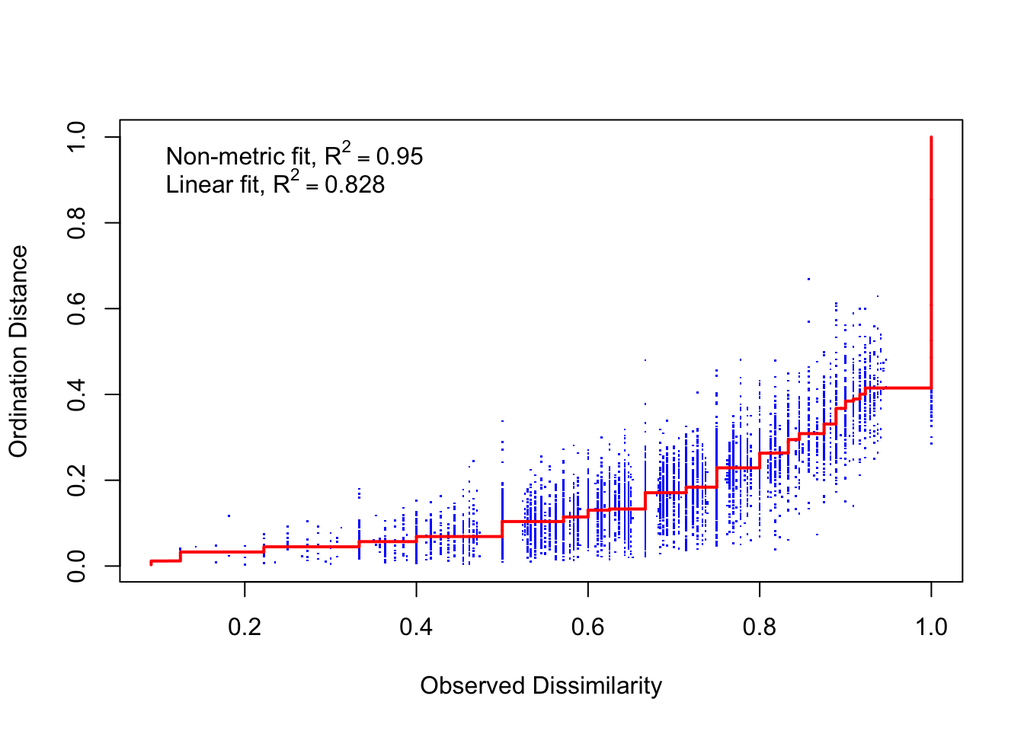

```r
stressplot(eel.nmds) #bleck
```

visualize it

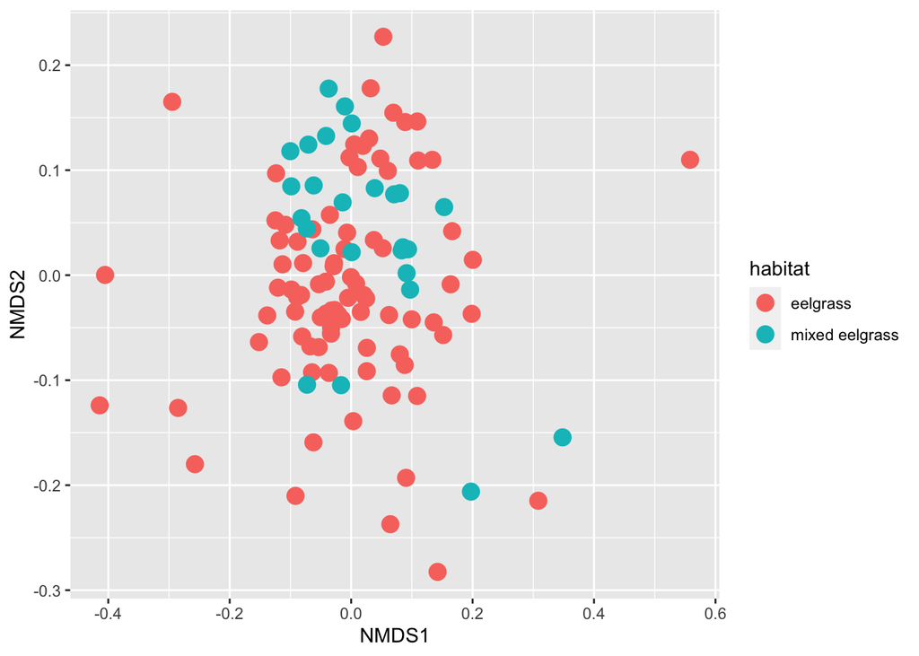

```r
scores(eel.nmds) %>%
  as_tibble(rownames = "SampleCode_rep") %>%
  inner_join(eel.site.byrep) %>%
  ggplot(aes(x = NMDS1, y = NMDS2, color = habitat)) +
  geom_point(size = 4) #+
```

```r
  #stat_ellipse() # is the default stat_ellipse what I want?
```

Regardless of how this plot look/turns out, the stress is too high to reliably represent these data in only 2 dimensions.

### PCoA

I think potentially the better approach is to visualize this data in two dimensions with PCoA rather than nmds because it would require 3 dimensions to better visualize it.

```r
pco.eel <- cmdscale(eel.jacc, k = 2, eig = T, add = T)
colnames(pco.eel$points) <- c("pcoa1", "pcoa2")
# eiganvector - positions on the x and y axis (points)
# eiganvalues - indicate something about the proportion of the variation explained by the different axis. So we can use eiganvalues to get porpotion explained. Some of these eiganvalues are negative. Need to be rescaled (this is done by add = T)

percent_explained2 <- 100* pco.eel$eig/ sum(pco.eel$eig)
pe2 <- format(round(percent_explained2[1:2], digits = 1), nsmall = 1, trim = T)

labs.eel <- c(glue("PCoA 1 ({pe2[1]}%)"),
          glue("PcoA 2 ({pe2[2]}%)"))
```

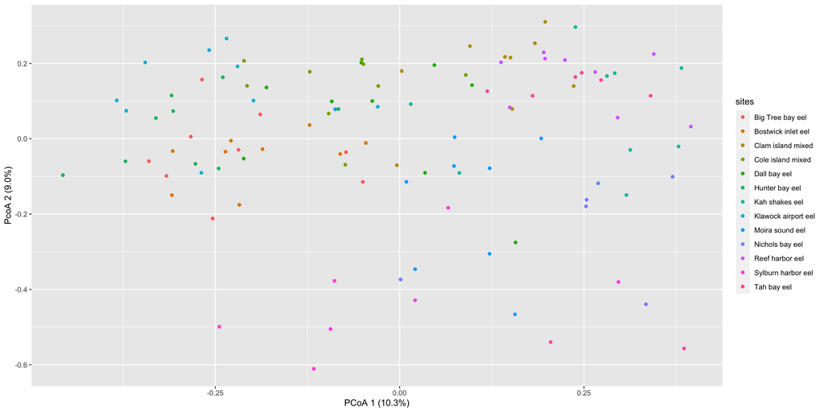

```r
pco.eel$points %>%
  as_tibble(rownames = "SampleCode_rep") %>%
  left_join(eel.site.byrep, by = "SampleCode_rep") %>%
  ggplot(aes(x = pcoa1, y = pcoa2, color = sites)) +
  geom_point() + labs(x = labs.eel[1], y = labs.eel[2])
```

scree plot

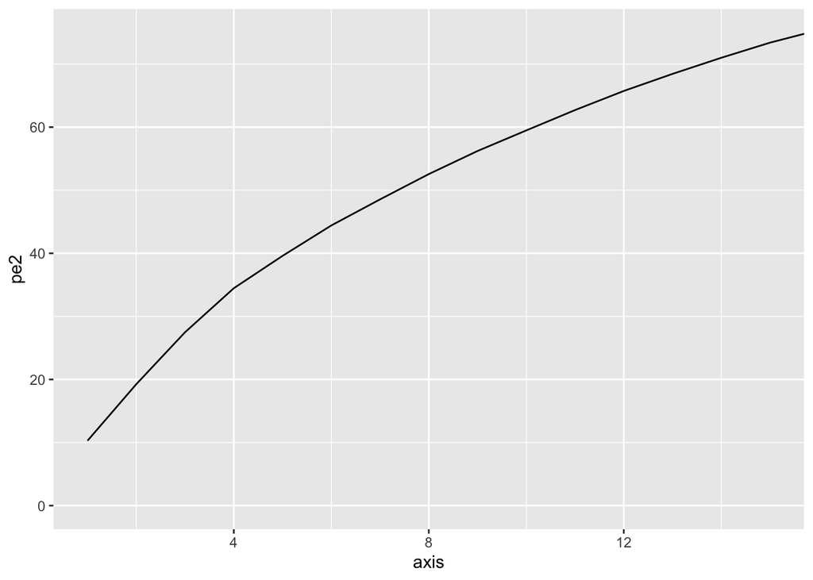

```r
# create scree plot that shows the percent explained
tibble(pe2 = cumsum(percent_explained2),
       axis = 1:length(percent_explained2)) %>%
  ggplot(aes(x = axis, y = pe2)) +
  geom_line() +
  coord_cartesian(xlim = c(1,15), ylim = c(0, 75))
```

Okay overall, the eDNA is arguably potentially more variable than seine data (or variable in a different way). Things I’m unsure with how to deal:

- Should I be combining the unique data from the technical replciates together? There are instances (that occur frequently) where one technical replicate will have different species occurrence than the other technical replicates.
- Why do the technical replicates end up so different? Aren’t they supposed to be exact replicates mainly used for looking at any lab variability?
- We dealt with the controls by subtracting the control read counts from the ASV present in each of the field/technical replciates - Is this the appropriate way of doing this? This doesn’t account for the proportional/compositional nature of the data that forces the sum to 1 requirement. In the control, there are likely less genetic material so its more likely (imo) for that material to be artifically exponenetially inflatted.
- in each unique eDNA field/tech replciate unit we found between 0 - 17 species occurrences. This seems somewhat low compared to the beach seine data. Whats happening here?

# 2.3 Seine data and eDNA

Next step in the analysis is to add in the beach seine data, but in order to compare it to the eDNA data we need to match up the species/taxonomic groups. This is going to take some data manipulation

- read in seine data - how many species did we find per seine?
- what groups can we group the seine data into to best match the eDNA data, for example I know we’ll need to group the eDNA data for artedius sculpins into artedius in general because we have low confidence in identifying our lil’ artedius sculpins in the field.
- calculate P/A for beach seinee and combine with eDNA
- run MV approaches

```r
head(seine)
```

```
##   bay_code bay_sample     place_name  habitat so_region     date YYYYMMDD
## 1     SYLB          A Sylburn harbor eelgrass      none 6/8/2021 20210608
## 2     SYLB          A Sylburn harbor eelgrass      none 6/8/2021 20210608
## 3     SYLB          A Sylburn harbor eelgrass      none 6/8/2021 20210608
## 4     SYLB          A Sylburn harbor eelgrass      none 6/8/2021 20210608
## 5     SYLB          A Sylburn harbor eelgrass      none 6/8/2021 20210608
## 6     SYLB          A Sylburn harbor eelgrass      none 6/8/2021 20210608
##   start_time end_time slope tide_height tide_time    species_common
## 1        600      630 steep        -0.5       632       Pink salmon
## 2        600      630 steep        -0.5       632       Pink salmon
## 3        600      630 steep        -0.5       632       Chum salmon
## 4        600      630 steep        -0.5       632 Snake prickleback
## 5        600      630 steep        -0.5       632 Snake prickleback
## 6        600      630 steep        -0.5       632 Snake prickleback
##       species_scientific sp_code fork_length unmeasured unmeasured_sm
## 1 Oncorhynchus gorbuscha SALPINK          62         NA            NA
## 2 Oncorhynchus gorbuscha SALPINK          98         NA            NA
## 3      Oncorhynchus keta SALCHUM         115         NA            NA
## 4       Lumpenus sagitta PRICKSN         138         NA            NA
## 5       Lumpenus sagitta PRICKSN         145         NA            NA
## 6       Lumpenus sagitta PRICKSN         149         NA            NA
##        taxon Sex notes FL_checking same.
## 1 vertebrate                    62  TRUE
## 2 vertebrate                    98  TRUE
## 3 vertebrate                   115  TRUE
## 4 vertebrate                   138  TRUE
## 5 vertebrate                   145  TRUE
## 6 vertebrate                   149  TRUE
```

```r
unique(seine$unmeasured) # there are some unmeasured fishes
```

```
##  [1]   NA   17   20    3    5  183   11    1  967 1126   65  612   26    2   92
## [16]  217  110    4  411   32   59   10   88   22   55   48   24  196   86  134
## [31]   71   44   53  198   97   61   19   35  116  142 1270  126   21  222  266
## [46]  480    9
```

```r
unique(seine$unmeasured_sm)
```

```
## [1]  NA  10 306  61  29 107  39  42  32
```

```r
unique(seine$species_scientific) # have 64 unique speices approximately
```

```
##  [1] "Oncorhynchus gorbuscha"            "Oncorhynchus keta"
##  [3] "Lumpenus sagitta"                  "Anoplarchus insignis"
##  [5] "Syngnathus leptorhynchus"          "Sebastes sp"
##  [7] "Hexagrammos lagocephalus"          "Hexagrammos stelleri"
##  [9] "Pholis laeta"                      "Cymatogaster aggregata"
## [11] "Leptocottus armatus"               "Cottidae"
## [13] "Myoxocephalus polyacanthocephalus" "Artedius spp."
## [15] "Pugettia producta, Majidae"        "Temessus cheiragonus"
## [17] "Cancer productus, Cancridae"       "Sebastes caurinus"
## [19] "Sebastes maliger"                  "Oncorhynchus kisutch"
## [21] "Brachyistius frenatus"             "Oxylebius pictus"
## [23] "Rhinogobiops nicholsii"            "Enophrys bison"
## [25] "Gadus macrocephalus"               "Blepsias cirrhosus"
## [27] "Ophiodon elongatus"                "Nautichthys oculofasciatus"
## [29] ""                                  "Limanda aspera"
```

[output cut: 17 more lines]

```r
unique(seine$place_name)
```

```
##  [1] "Sylburn harbor"        "Reef harbor"           "Kah shakes"
##  [4] "Dall Bay"              "Moira Sound"           "Reef Harbor"
##  [7] "Nichols Bay"           "Tah Bay"               "Hunter Bay"
## [10] "Port Refugio"          "North Fish Egg Island" "Shinaku Inlet"
## [13] "Nossuk Bay"            "Guktu Bay"             "Natzuhini Bay"
## [16] "Bostwick Inlet"
```

```r
# calculate total abundance
seine$abundance <- as.numeric(ifelse(is.na(seine$fork_length), ifelse(is.na(seine$unmeasured), paste(seine$unmeasured_sm), paste(seine$unmeasured)), 1))
# fish taxon for an entry of shiner perch
seine$taxon <- as.factor(seine$taxon)
levels(seine$taxon)[levels(seine$taxon)==""] <- "vertebrate"
seine$taxon <- as.character(seine$taxon)

# join in the habitat information and site names
loc.chp3 <- cbind(chp3, bay_id)

seine2 <- seine %>%
  filter(taxon == "vertebrate") %>%
  unite(bay_id, bay_code:bay_sample)

seine2$bay_id <- trimws(seine2$bay_id)
sgwd <- c("REFU_A", "NEFI_A", "NOSK_A", "SHIN_A", "NATZ_A", "GUKT_A")

fish <- seine2 %>%
  dplyr::select(-c(FL_checking:same., so_region, fork_length, Sex, unmeasured, unmeasured_sm, notes)) %>%
  subset(!(bay_id %in% sgwd)) %>%
  left_join(loc.chp3, by = c("bay_id")) %>%
  rename(habitat = habitat.y) %>%
  dplyr::select(-habitat.x)


unique(fish$bay_id) # 16 seine sites - consistent
```

```
##  [1] "SYLB_A" "SYLB_B" "REEF_A" "KAHS_A" "KAHS_B" "DALL_A" "MOIR_B" "DALL_B"
##  [9] "MOIR_A" "REEF_B" "NICH_B" "NICH_A" "TAHB_A" "HUNT_A" "BOST_A" "BOST_B"
```

```r
unique(fish$species_scientific) # 48 species for the seines, when we add back fourmissing sites now 51 species
```

```
##  [1] "Oncorhynchus gorbuscha"            "Oncorhynchus keta"
##  [3] "Lumpenus sagitta"                  "Anoplarchus insignis"
##  [5] "Syngnathus leptorhynchus"          "Sebastes sp"
##  [7] "Hexagrammos lagocephalus"          "Hexagrammos stelleri"
##  [9] "Pholis laeta"                      "Cymatogaster aggregata"
## [11] "Leptocottus armatus"               "Cottidae"
## [13] "Myoxocephalus polyacanthocephalus" "Artedius spp."
## [15] "Sebastes caurinus"                 "Sebastes maliger"
## [17] "Oncorhynchus kisutch"              "Brachyistius frenatus"
## [19] "Oxylebius pictus"                  "Rhinogobiops nicholsii"
## [21] "Enophrys bison"                    "Gadus macrocephalus"
## [23] "Blepsias cirrhosus"                "Ophiodon elongatus"
## [25] "Nautichthys oculofasciatus"        "Limanda aspera"
## [27] "Parophrys vetulus"                 "Aulorhynchus flavidus"
## [29] "Podothecus accipenserinus"         "Apodichthys flavidus"
## [31] "Citharichthys sordidus"            "Pleuronectidae"
## [33] "Ammodytes personatus"              "Lepidopsetta spp."
## [35] "Pleuronichthys coenosus"           "Hemilepidotus hemilepidotus"
## [37] "Hemilepidotus sp."                 "Gasterosteus aculeatus"
## [39] "Hexagrammos decagrammus"           "Hexagrammos octogrammus"
## [41] "Citharichthys stigmaeus"           "Division Teleostei"
## [43] "Clupea pallasii"                   "Salvelinus malma"
## [45] "Ronquilus jordani"                 "Sebastes melanops"
## [47] "Lepidogobius lepidus"              "Platichthys stellatus"
## [49] "Pallasina barbata"                 "Oncorhynchus nerka"
## [51] "Oncorhynchus clarkii"
```

```r
names(edna.bin.samplecode_rep2)
```

```
##  [1] "Pholis"                     "Oncorhynchus"
##  [3] "Salmonidae"                 "Cymatogaster_aggregata"
##  [5] "Clupeidae"                  "Citharichthys_stigmaeus"
##  [7] "Ammodytidae"                "Oligocottus"
##  [9] "Hexagrammos"                "Syngnathus_leptorhynchus"
## [11] "Gadidae"                    "Sebastidae"
## [13] "Stichaeidae"                "Anoplarchus"
## [15] "Cottidae"                   "Clinocottus_acuticeps"
## [17] "Apodichthys_flavidus"       "Enophrys_bison"
## [19] "Actinopteri"                "Polypera_greeni"
## [21] "Hemilepidotus"              "Chitonotus_pugetensis"
## [23] "Pleuronectidae"             "Gobiesox_maeandricus"
## [25] "Artedius_lateralis"         "Gasterosteus"
## [27] "Artedius_fenestralis"       "Artedius_harringtoni"
## [29] "Anoplopoma_fimbria"         "Oxylebius_pictus"
## [31] "Aulorhynchus_flavidus"      "Rhamphocottus_richardsonii"
## [33] "Nautichthys_oculofasciatus" "Lepidogobius_lepidus"
## [35] "Liparis_fucensis"           "Brachyistius_frenatus"
## [37] "Megaptera_novaeangliae"     "Embiotocidae"
## [39] "Synchirus_gilli"            "Ophiodon_elongatus"
## [41] "Pleuronichthys"             "Enhydra_lutris"
## [43] "Citharichthys_sordidus"     "Brosmophycis_marginata"
## [45] "Leptocottus_armatus"        "Agonidae"
```

## grouping eDNA/seine data

We need to group the eDNA/seine data into greater genus/family depending on the situation

```r
# Oncorhynchus/Salmonidae - seine
Salmon <- c("Oncorhynchus gorbuscha", "Oncorhynchus keta", "Salvelinus malma", "Oncorhynchus nerka", "Oncorhynchus kisutch",
            "Oncorhynchus clarkii")

## eDNA
eSalmonidae <- c("Salmonidae", "Oncorhynchus")

# family Embiotocidae - seine
Embiotocidae <- c("Brachyistius frenatus", "Cymatogaster aggregata")
# eDNA
eEmbiotocidae <- c("Brachyistius_frenatus", "Cymatogaster_aggregata")

# Clupidae (family) - seine
Clupidae <- c("Clupea pallasii")

# Ammodytidae - seine
Ammodytidae <- "Ammodytes personatus"

# Cottidae - seine
Cottidae <- c("Leptocottus armatus", "Cottidae", "Myoxocephalus polyacanthocephalus",
                "Artedius spp.", "Enophrys bison", "Hemilepidotus sp.", "Hemilepidotus hemilepidotus")
## eDNA
eCottidae <- c("Clinocottus_acuticeps", "Chitonotus_pugetensis", "Artedius_fenestralis", "Artedius_harringtoni",
               "Artedius_lateralis", "Enophrys_bison", "Leptocottus_armatus", "Synchirus_gilli", "Hemilepidotus",
               "Oligocottus")

# Gadidae - seine
Gadidae <- "Gadus macrocephalus"

# Hexagrammidae - seine
Hexagrammidae <- c("Hexagrammos decagrammus", "Hexagrammos octogrammus", "Hexagrammos lagocephalus",
                     "Hexagrammos stelleri", "Ophiodon elongatus", "Oxylebius pictus")
## eDNA
eHexagrammidae <- c("Hexagrammos", "Oxylebius_pictus", "Ophiodon_elongatus")

# Sebastes sp - seine
Sebastidae <- c("Sebastes sp", "Sebastes caurinus", "Sebastes maliger", "Sebastes melanops")

# Anoplarchus insignis - slender cockscomb - seine
Stichaeidae <- c("Anoplarchus insignis", "Lumpenus sagitta")
## eDNA
eStichaeidae <- c("Anoplarchus", "Stichaeidae")

# Pholis - seine, family
Pholidae <- c("Pholis laeta", "Apodichthys flavidus", "Pholis")
## eDNA pholis
ePholidae <- c("Pholis", "Apodichthys_flavidus")

# Agonidae (Poachers) - seine
Agonidae <- c("Pallasina barbata", "Podothecus accipenserinus")

## eDNA
# areAgnoidae

## Flatfishes ## seine
# Citharichthys right now keep as species specific found in both seine and eDNA
# change the seine data

# right eyed flatfishes
Pleuronectidae <- c("Parophrys vetulus", "Pleuronichthys coenosus", "Limanda aspera", "Lepidopsetta spp.", "Platichthys stellatus")
## edna
ePleuronectidae <- c("Pleuronichthys", "Pleuronectidae")

# three spines- Gasterosteus
Gasterosteus <- c("Gasterosteus aculeatus")

# higher order
Teleostei <- c("Division Teleostei")
eTeleostei <- c("Actinopteri")

fish$species_scientific <- sapply(fish["species_scientific"], function(x) replace(x, x %in% Salmon, "Salmonidae"))
fish$species_scientific <- sapply(fish["species_scientific"], function(x) replace(x, x %in% Embiotocidae, "Embiotocidae"))
fish$species_scientific <- sapply(fish["species_scientific"], function(x) replace(x, x %in% Clupidae, "Clupidae"))
fish$species_scientific <- sapply(fish["species_scientific"], function(x) replace(x, x %in% Ammodytidae, "Ammodytidae"))
fish$species_scientific <- sapply(fish["species_scientific"], function(x) replace(x, x %in% Cottidae, "Cottidae"))
fish$species_scientific <- sapply(fish["species_scientific"], function(x) replace(x, x %in% Gadidae, "Gadidae"))
fish$species_scientific <- sapply(fish["species_scientific"], function(x) replace(x, x %in% Hexagrammidae, "Hexagrammidae"))
fish$species_scientific <- sapply(fish["species_scientific"], function(x) replace(x, x %in% Sebastidae, "Sebastidae"))
fish$species_scientific <- sapply(fish["species_scientific"], function(x) replace(x, x %in% Pholidae, "Pholidae"))
fish$species_scientific <- sapply(fish["species_scientific"], function(x) replace(x, x %in% Stichaeidae, "Stichaeidae"))
fish$species_scientific <- sapply(fish["species_scientific"], function(x) replace(x, x %in% Agonidae, "Agonidae"))
fish$species_scientific <- sapply(fish["species_scientific"], function(x) replace(x, x %in% Pleuronectidae, "Pleuronectidae"))
fish$species_scientific <- sapply(fish["species_scientific"], function(x) replace(x, x %in% Gasterosteus, "Gasterosteus"))
fish$species_scientific <- sapply(fish["species_scientific"], function(x) replace(x, x %in% Teleostei, "Teleostei"))


fish$species_scientific <- fish$species_scientific[,1]
str(fish)
```

```
## 'data.frame':    2594 obs. of  16 variables:
##  $ bay_id            : chr  "SYLB_A" "SYLB_A" "SYLB_A" "SYLB_A" ...
##  $ place_name        : chr  "Sylburn harbor" "Sylburn harbor" "Sylburn harbor" "Sylburn harbor" ...
##  $ date              : chr  "6/8/2021" "6/8/2021" "6/8/2021" "6/8/2021" ...
##  $ YYYYMMDD          : int  20210608 20210608 20210608 20210608 20210608 20210608 20210608 20210608 20210608 20210608 ...
##  $ start_time        : int  600 600 600 600 600 600 600 600 600 600 ...
##  $ end_time          : int  630 630 630 630 630 630 630 630 630 630 ...
##  $ slope             : chr  "steep" "steep" "steep" "steep" ...
##  $ tide_height       : num  -0.5 -0.5 -0.5 -0.5 -0.5 -0.5 -0.5 -0.5 -0.5 -0.5 ...
##  $ tide_time         : int  632 632 632 632 632 632 632 632 632 632 ...
##  $ species_common    : chr  "Pink salmon" "Pink salmon" "Chum salmon" "Snake prickleback" ...
##  $ species_scientific: chr  "Salmonidae" "Salmonidae" "Salmonidae" "Stichaeidae" ...
##  $ sp_code           : chr  "SALPINK" "SALPINK" "SALCHUM" "PRICKSN" ...
##  $ taxon             : chr  "vertebrate" "vertebrate" "vertebrate" "vertebrate" ...
##  $ abundance         : num  1 1 1 1 1 1 1 1 1 1 ...
##  $ sites             : chr  "Sylburn harbor eel" "Sylburn harbor eel" "Sylburn harbor eel" "Sylburn harbor eel" ...
##  $ habitat           : chr  "eelgrass" "eelgrass" "eelgrass" "eelgrass" ...
```

```r
fish$species_scientific <- as.factor(fish$species_scientific)
```

```r
# change the eDNA data
edna.long <- edna.bin.sp %>%
  rownames_to_column(var = "SampleCode_rep") %>%
  dplyr::select(-c(Enhydra_lutris, Megaptera_novaeangliae)) %>%
  pivot_longer(cols = Actinopteri:Syngnathus_leptorhynchus, names_to = "species_scientific", values_to = "binary")

edna.long$species_scientific <- sapply(edna.long["species_scientific"], function(x) replace(x, x %in% eSalmonidae, "Salmonidae"))
edna.long$species_scientific <- sapply(edna.long["species_scientific"], function(x) replace(x, x %in% eEmbiotocidae, "Embiotocidae"))
edna.long$species_scientific <- sapply(edna.long["species_scientific"], function(x) replace(x, x %in% eCottidae, "Cottidae"))
edna.long$species_scientific <- sapply(edna.long["species_scientific"], function(x) replace(x, x %in% eHexagrammidae, "Hexagrammidae"))
edna.long$species_scientific <- sapply(edna.long["species_scientific"], function(x) replace(x, x %in% ePholidae, "Pholidae"))
edna.long$species_scientific <- sapply(edna.long["species_scientific"], function(x) replace(x, x %in% eStichaeidae, "Stichaeidae"))
edna.long$species_scientific <- sapply(edna.long["species_scientific"], function(x) replace(x, x %in% ePleuronectidae, "Pleuronectidae"))
edna.long$species_scientific <- sapply(edna.long["species_scientific"], function(x) replace(x, x %in% eTeleostei, "Teleostei"))

edna.long$species_scientific <- edna.long$species_scientific[,1]
str(edna.long)
```

```
## tibble [2,596 × 3] (S3: tbl_df/tbl/data.frame)
##  $ SampleCode_rep    : chr [1:2596] "2021_BOST_A_1" "2021_BOST_A_1" "2021_BOST_A_1" "2021_BOST_A_1" ...
##  $ species_scientific: chr [1:2596] "Teleostei" "Agonidae" "Ammodytidae" "Stichaeidae" ...
##  $ binary            : num [1:2596] 1 0 0 0 0 0 0 0 0 0 ...
```

```r
edna.long$species_scientific <- gsub("_", " ", edna.long$species_scientific)

# check the species in seines and eDNA
levels(as.factor(fish$species_scientific))
```

```
##  [1] "Agonidae"                   "Ammodytidae"
##  [3] "Aulorhynchus flavidus"      "Blepsias cirrhosus"
##  [5] "Citharichthys sordidus"     "Citharichthys stigmaeus"
##  [7] "Clupidae"                   "Cottidae"
##  [9] "Embiotocidae"               "Gadidae"
## [11] "Gasterosteus"               "Hexagrammidae"
## [13] "Lepidogobius lepidus"       "Nautichthys oculofasciatus"
## [15] "Pholidae"                   "Pleuronectidae"
## [17] "Rhinogobiops nicholsii"     "Ronquilus jordani"
## [19] "Salmonidae"                 "Sebastidae"
## [21] "Stichaeidae"                "Syngnathus leptorhynchus"
## [23] "Teleostei"
```

```r
levels(as.factor(edna.long$species_scientific))
```

```
##  [1] "Agonidae"                   "Ammodytidae"
##  [3] "Anoplopoma fimbria"         "Aulorhynchus flavidus"
##  [5] "Brosmophycis marginata"     "Citharichthys sordidus"
##  [7] "Citharichthys stigmaeus"    "Clupeidae"
##  [9] "Cottidae"                   "Embiotocidae"
## [11] "Gadidae"                    "Gasterosteus"
## [13] "Gobiesox maeandricus"       "Hexagrammidae"
## [15] "Lepidogobius lepidus"       "Liparis fucensis"
## [17] "Nautichthys oculofasciatus" "Pholidae"
## [19] "Pleuronectidae"             "Polypera greeni"
## [21] "Rhamphocottus richardsonii" "Salmonidae"
## [23] "Sebastidae"                 "Stichaeidae"
## [25] "Syngnathus leptorhynchus"   "Teleostei"
```

Okay so now we’ve figured out where these species can overlap and “rounded up” taxonomically for instances where eDNA only was able to identify species to the genus or family level - lets combine the data frames

```r
glimpse(fish)
```

```
## Rows: 2,594
## Columns: 16
## $ bay_id             <chr> "SYLB_A", "SYLB_A", "SYLB_A", "SYLB_A", "SYLB_A", "…
## $ place_name         <chr> "Sylburn harbor", "Sylburn harbor", "Sylburn harbor…
## $ date               <chr> "6/8/2021", "6/8/2021", "6/8/2021", "6/8/2021", "6/…
## $ YYYYMMDD           <int> 20210608, 20210608, 20210608, 20210608, 20210608, 2…
## $ start_time         <int> 600, 600, 600, 600, 600, 600, 600, 600, 600, 600, 6…
## $ end_time           <int> 630, 630, 630, 630, 630, 630, 630, 630, 630, 630, 6…
## $ slope              <chr> "steep", "steep", "steep", "steep", "steep", "steep…
## $ tide_height        <dbl> -0.5, -0.5, -0.5, -0.5, -0.5, -0.5, -0.5, -0.5, -0.…
## $ tide_time          <int> 632, 632, 632, 632, 632, 632, 632, 632, 632, 632, 6…
## $ species_common     <chr> "Pink salmon", "Pink salmon", "Chum salmon", "Snake…
## $ species_scientific <fct> Salmonidae, Salmonidae, Salmonidae, Stichaeidae, St…
## $ sp_code            <chr> "SALPINK", "SALPINK", "SALCHUM", "PRICKSN", "PRICKS…
## $ taxon              <chr> "vertebrate", "vertebrate", "vertebrate", "vertebra…
## $ abundance          <dbl> 1, 1, 1, 1, 1, 1, 1, 1, 1, 1, 1, 1, 1, 1, 1, 1, 1, …
## $ sites              <chr> "Sylburn harbor eel", "Sylburn harbor eel", "Sylbur…
## $ habitat            <chr> "eelgrass", "eelgrass", "eelgrass", "eelgrass", "ee…
```

```r
glimpse(edna.long)
```

```
## Rows: 2,596
## Columns: 3
## $ SampleCode_rep     <chr> "2021_BOST_A_1", "2021_BOST_A_1", "2021_BOST_A_1", …
## $ species_scientific <chr> "Teleostei", "Agonidae", "Ammodytidae", "Stichaeida…
## $ binary             <dbl> 1, 0, 0, 0, 0, 0, 0, 0, 0, 0, 0, 0, 0, 0, 0, 0, 1, …
```

```r
fish$gear <- "beach_seine"

seine.info <- fish %>%
  dplyr::select(place_name:tide_time, bay_id, habitat) %>%
  distinct()

sp.info <- fish %>%
  dplyr::select(c(bay_id, place_name, habitat, species_common, species_scientific, sp_code))

fish$species_scientific <- as.character(fish$species_scientific)

fish2 <- fish %>%
  dplyr::group_by(bay_id, sites, species_scientific) %>%
  dplyr::mutate(counts = sum(abundance)) %>%
  dplyr::select(-abundance) %>%
  distinct() %>%
  unite(bay_id_gear, c(bay_id, gear)) %>%
  ungroup() %>%
  distinct() %>%
  dplyr::select(c(bay_id_gear, species_scientific, counts)) %>%
  group_by(bay_id_gear, species_scientific) %>%
  dplyr::summarise(counts2 = sum(counts)) %>%
  mutate(binary = if_else(counts2 > 0, 1, 0)) %>%
  dplyr::select(-counts2) %>%
  distinct()
glimpse(fish2)
```

```
## Rows: 154
## Columns: 3
## Groups: bay_id_gear [16]
## $ bay_id_gear        <chr> "BOST_A_beach_seine", "BOST_A_beach_seine", "BOST_A…
## $ species_scientific <chr> "Ammodytidae", "Cottidae", "Embiotocidae", "Pholida…
## $ binary             <dbl> 1, 1, 1, 1, 1, 1, 1, 1, 1, 1, 1, 1, 1, 1, 1, 1, 1, …
```

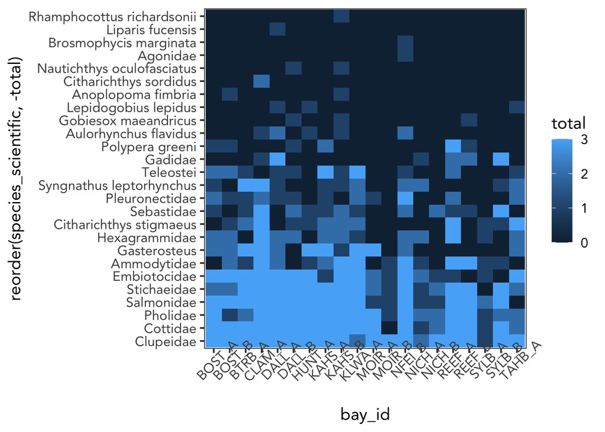

```r
# options here when dealing with the eDNA.long, we can either keep the field replicates separate (as the following) or we can combine the replicates together
edna.by.rep <- edna.long %>%
  separate(SampleCode_rep, into = c("year", "bay_code", "bay_letter", "rep")) %>%
  unite(bay_id, bay_code:bay_letter) %>%
  group_by(bay_id, species_scientific, rep) %>%
  dplyr::mutate(total = sum(binary)) %>%
  dplyr::select(-binary) %>%
  mutate(binary = if_else(total > 0, 1, 0)) %>%
  dplyr::select(-total) %>%
  distinct()


edna.by.rep %>%
  group_by(bay_id, species_scientific) %>%
  dplyr::summarize(total = sum(binary)) %>%
  ggplot() +
  geom_tile(aes(x = bay_id, y = reorder(species_scientific, -total), fill = total)) +
  plot_theme() +
  theme(axis.text.x = element_text(angle = 45))
```

```r
edna.by.rep$gear <- "eDNA"

edna.by.site <- edna.by.rep %>%
  group_by(bay_id, species_scientific, gear) %>%
  dplyr::summarise(total = sum(binary)) %>%
  distinct() %>%
  mutate(binary = if_else(total > 0, 1, 0)) %>%
  dplyr::select(-total) %>%
  distinct() %>%
  unite(bay_id_gear, c(bay_id, gear))
# combine beach seine and eDNA data, by site by species and pivot wide
full.dat <- rbind(fish2, edna.by.site) %>%
  pivot_wider(names_from = "species_scientific", values_from = "binary", values_fill = 0) %>%
  column_to_rownames("bay_id_gear")
head(full.dat)
```

```
##                    Ammodytidae Cottidae Embiotocidae Pholidae
## BOST_A_beach_seine           1        1            1        1
## BOST_B_beach_seine           0        1            1        1
## DALL_A_beach_seine           0        1            1        1
## DALL_B_beach_seine           1        1            1        1
## HUNT_A_beach_seine           0        1            1        1
## KAHS_A_beach_seine           0        1            1        1
##                    Syngnathus leptorhynchus Aulorhynchus flavidus Hexagrammidae
## BOST_A_beach_seine                        1                     0             0
## BOST_B_beach_seine                        1                     1             1
## DALL_A_beach_seine                        1                     1             1
## DALL_B_beach_seine                        0                     0             1
## HUNT_A_beach_seine                        1                     0             0
## KAHS_A_beach_seine                        1                     1             1
##                    Pleuronectidae Salmonidae Citharichthys stigmaeus Gadidae
## BOST_A_beach_seine              0          0                       0       0
## BOST_B_beach_seine              1          1                       0       0
## DALL_A_beach_seine              1          1                       1       1
## DALL_B_beach_seine              0          1                       0       0
## HUNT_A_beach_seine              0          1                       0       0
## KAHS_A_beach_seine              1          1                       0       1
##                    Gasterosteus Stichaeidae Teleostei Clupidae Sebastidae
## BOST_A_beach_seine            0           0         0        0          0
## BOST_B_beach_seine            0           0         0        0          0
## DALL_A_beach_seine            1           1         1        0          0
## DALL_B_beach_seine            1           0         0        1          1
## HUNT_A_beach_seine            1           1         0        0          0
## KAHS_A_beach_seine            1           0         0        0          1
##                    Agonidae Citharichthys sordidus Blepsias cirrhosus
## BOST_A_beach_seine        0                      0                  0
## BOST_B_beach_seine        0                      0                  0
## DALL_A_beach_seine        0                      0                  0
## DALL_B_beach_seine        0                      0                  0
## HUNT_A_beach_seine        1                      1                  0
## KAHS_A_beach_seine        0                      0                  1
##                    Rhinogobiops nicholsii Ronquilus jordani
## BOST_A_beach_seine                      0                 0
## BOST_B_beach_seine                      0                 0
## DALL_A_beach_seine                      0                 0
## DALL_B_beach_seine                      0                 0
```

[output cut: 15 more lines]

```
## KAHS_A_beach_seine                  0                      0         0
##                    Gobiesox maeandricus Liparis fucensis Polypera greeni
## BOST_A_beach_seine                    0                0               0
## BOST_B_beach_seine                    0                0               0
## DALL_A_beach_seine                    0                0               0
## DALL_B_beach_seine                    0                0               0
## HUNT_A_beach_seine                    0                0               0
## KAHS_A_beach_seine                    0                0               0
##                    Rhamphocottus richardsonii
## BOST_A_beach_seine                          0
## BOST_B_beach_seine                          0
## DALL_A_beach_seine                          0
## DALL_B_beach_seine                          0
## HUNT_A_beach_seine                          0
## KAHS_A_beach_seine                          0
```